# 備忘録_from2025_July_14

### プロテオーム解析で取れた残りの遺伝子の解析

卵周りの物質から取れた遺伝子のうち、卵/卵蓋ゼリーの割合が高い4つについて調べる

- SM1_g8639.t2
- SM1_g4416.t1
- SM1_2566.t1
- SM1_g12995.t1

#### SM1_g8639.t2

[figure not shown]

`Smad_g7180.t1 SM1_g8639.t2`  
eggNogMapperでアノテーションつかず  
NCBIドメインサーチでもドメイン不明

OG関係

```bash
OG0008894
Agra_P_050301079.1, Agra_P_050307630.1
Ebra_g1777.t1, Ebra_g1778.t1
Escr_g1880.t1, Escr_g1881.t1
Mtri_g7149.t1, Mtri_g7150.t1
SM1_g8638.t1, SM1_g8639.t2
```

5種の遺伝子が２コピーずつ

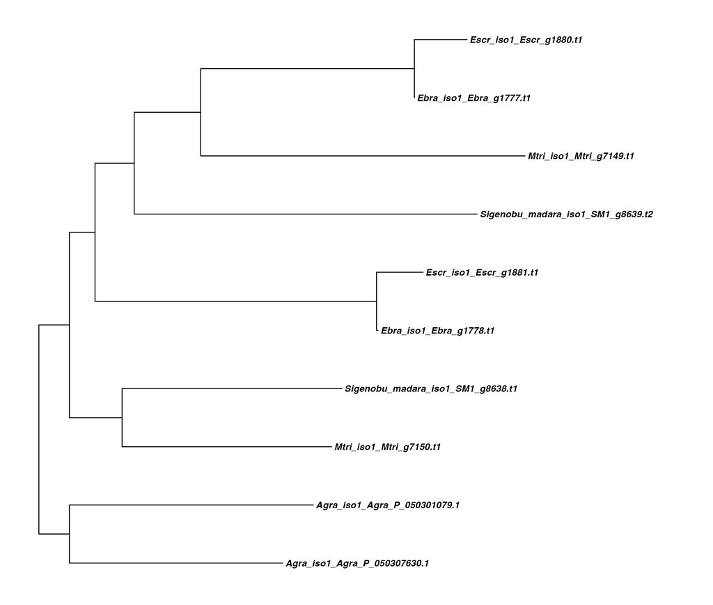

DEG・成虫と幼虫の比較

```bash
gene_ID adult.1 adult.2 adult.3 llarva.1    llarva.2    llarva.3    mlarva.1    mlarva.2    mlarva.3
g7180   28.41903138 1.642507702 2.013686643 0.335978014 0.186420053 0   0.662510801 0   0
```

**成虫で高発現！**

DEG・卵巣と体細胞の比較

```bash
gene_ID body.1  body.2  body.3  ovary.1 ovary.2 ovary.3 seed_ortholog
g7180   1.153761522 0.969825264 0.887269643 4812.004942 3643.532566 106.021321
```

**卵巣で高発現！**

#### SM1_g4416.t1

[figure not shown]

Sano_g3715と相同？でもRBHのファイルでは一致する遺伝子はなく、Sano_g3715はSM1_g5187.t1とRBHするという結果になっていた。**要検証**

```bash
>SM1_g4416.t1
MNTFAISSILMISLFFVFTQGAPQYEINVGRCNNLINKDIKHQELIHETKEVTKSYSVVP
STIYCLQVLNQNKNLRTAGTVEILSGGYQEEKVKLRFKPGNGSPAEFSLAVYAA
```

配列が短め  
eggNogMapperでアノテーションつかず  
NCBIドメインサーチでもドメイン不明

OG関係

```bash
OG0000185
Agra_P_050293136.1, Agra_P_050308793.1, Agra_P_050312408.1
Bmor_NP_001182380.2, Bmor_XP_004923446.1, Bmor_XP_004925541.1, Bmor_XP_004929726.1, Bmor_XP_004929727.2, Bmor_XP_004934347.2, Bmor_XP_037867428.1, Bmor_XP_062528542.1
Cass_AG9761562.1, Cass_AG9767031.1, Cass_AG9767131.1, Cass_AG9767132.1, Cass_AG9770972.1, Cass_AG9771459.1
Dmel_NP_001033959.1, Dmel_NP_001285405.1, Dmel_NP_001286050.1, Dmel_NP_001286370.1, Dmel_NP_573299.1, Dmel_NP_610833.1
Dpon_P_019755314.1, Dpon_P_019766538.1, Dpon_P_019771451.1, Dpon_P_019771452.1
Ebra_g11712.t1, Ebra_g2008.t1, Ebra_g6089.t1, Ebra_g6090.t1, Ebra_g6091.t1, Ebra_g6092.t1, Ebra_g6093.t1, Ebra_g6094.t1, Ebra_g7438.t1, Ebra_g9701.t1
Escr_g12512.t1, Escr_g2113.t1, Escr_g5241.t1, Escr_g7168.t1, Escr_g8985.t1, Escr_g9518.t1
Ldef_g11706.t1, Ldef_g18062.t1, Ldef_g20458.t1, Ldef_g22957.t1, Ldef_g23803.t1, Ldef_g2449.t1, Ldef_g9036.t1
Mtri_g10839.t1, Mtri_g1142.t1, Mtri_g1824.t1, Mtri_g252.t1, Mtri_g2702.t1
Orus_g12640.t1, Orus_g16905.t1, Orus_g21047.t1, Orus_g9687.t1, Orus_g9688.t1, Orus_g9689.t1, Orus_g9692.t1, Orus_g9693.t1
Pcer_g11893.t1, Pcer_g13149.t1, Pcer_g14637.t1, Pcer_g17923.t1, Pcer_g21896.t1, Pcer_g5687.t1, Pcer_g5688.t1, Pcer_g5689.t1, Pcer_g5690.t1
SM1_g10910.t1, SM1_g10911.t1, SM1_g10912.t1, SM1_g10913.t2, SM1_g10914.t1, SM1_g10915.t1, SM1_g11238.t1, SM1_g11350.t1, SM1_g11812.t1, SM1_g2850.t1, SM1_g4416.t1, SM1_g5186.t1, SM1_g5187.t1, SM1_g5188.t1, SM1_g5189.t1, SM1_g5190.t1, SM1_g5191.t1, SM1_g7121.t1
Sory_P_030749455.1, Sory_P_030749456.1, Sory_P_030753731.1, Sory_P_030753733.1, Sory_P_030756694.1
Tcas_P_001807284.2, Tcas_P_976138.1
```

14種で相同遺伝子を検出。短いだけあってオーソログ遺伝子も多い。

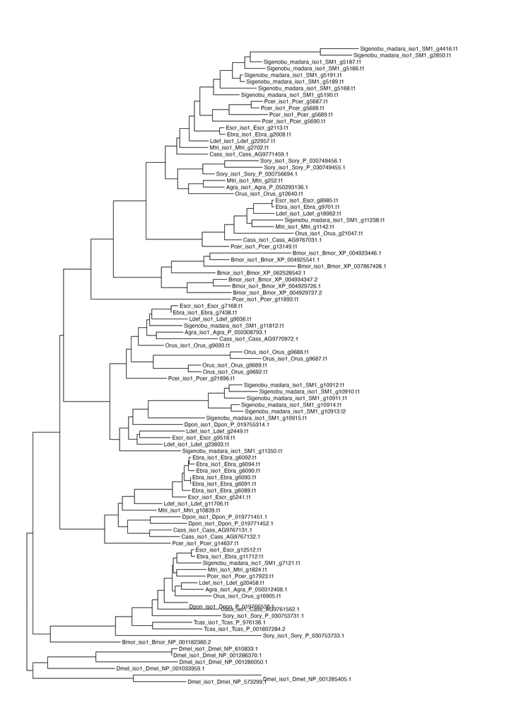

DEG・成虫と幼虫の比較

```bash
gene_ID adult.1 adult.2 adult.3 llarva.1    llarva.2    llarva.3    mlarva.1    mlarva.2    mlarva.3
g3715   24.37685818 4.869093979 9.380527839 9.312434079 2078.583591 16.98748039 8207.212611 9327.073269 8933.130825
```

mlarvaでめちゃくちゃ高発現

DEG・卵巣と体細胞の比較

```bash
gene_ID body.1  body.2  body.3  ovary.1 ovary.2 ovary.3 seed_ortholog
g3715   60.05428101 18.83109331 2.012709965 4748.352395 4103.849942 185.6043356
```

卵巣でめちゃくちゃ高発現

#### SM1_2566.t1

[figure not shown]

`Smad_g2209.t1 SM1_g2566.t1`  
EggNogのアノテーション

```bash
Smad_g2209.t1   367336.OM2255_00102 0.000782    46.6    COG3040@1|root,COG3040@2|Bacteria,1RDAI@1224|Proteobacteria,2U723@28211|Alphaproteobacteria 28211|Alphaproteobacteria   M   COG3040 Bacterial lipocalin -   -   -   ko:K03098   -   -   -   -   ko00000,ko04147 -   -   -   Lipocalin_2
```

OG関係

```bash
OG0000326
Agra_P_050304773.1, Agra_P_050309216.1, Agra_P_050314569.1, Agra_P_050314570.1
Bmor_NP_001036872.1, Bmor_NP_001140192.1, Bmor_XP_004921596.1, Bmor_XP_004932389.1, Bmor_XP_037876240.1 Cass_AG9759440.1    Dmel_NP_001259867.1, Dmel_NP_001260940.1
Dpon_P_019765308.1, Dpon_P_019765311.1, Dpon_P_019766593.1
Ebra_g1373.t1, Ebra_g1374.t1, Ebra_g9366.t1
Escr_g1430.t1, Escr_g1431.t1, Escr_g9326.t1
Ldef_g13438.t1, Ldef_g26763.t1, Ldef_g26764.t1, Ldef_g930.t1
Mtri_g10395.t1, Mtri_g10569.t1, Mtri_g791.t1, Mtri_g794.t1
Orus_g11041.t1, Orus_g20773.t2, Orus_g20775.t1, Orus_g20776.t1, Orus_g623.t1, Orus_g624.t1, Orus_g625.t1, Orus_g626.t1, Orus_g627.t1, Orus_g630.t1, Orus_g631.t1, Orus_g8680.t1
Pcer_g17550.t1, Pcer_g17551.t1, Pcer_g23780.t1, Pcer_g23800.t1, Pcer_g9733.t1
SM1_g1010.t1, SM1_g11231.t1, SM1_g11233.t1, SM1_g11464.t1, SM1_g11867.t1, SM1_g13386.t1, SM1_g2566.t1, SM1_g3906.t1, SM1_g7210.t1
Sory_P_030748329.1, Sory_P_030757212.1
Tcas_P_008199365.1, Tcas_P_015838652.1
```

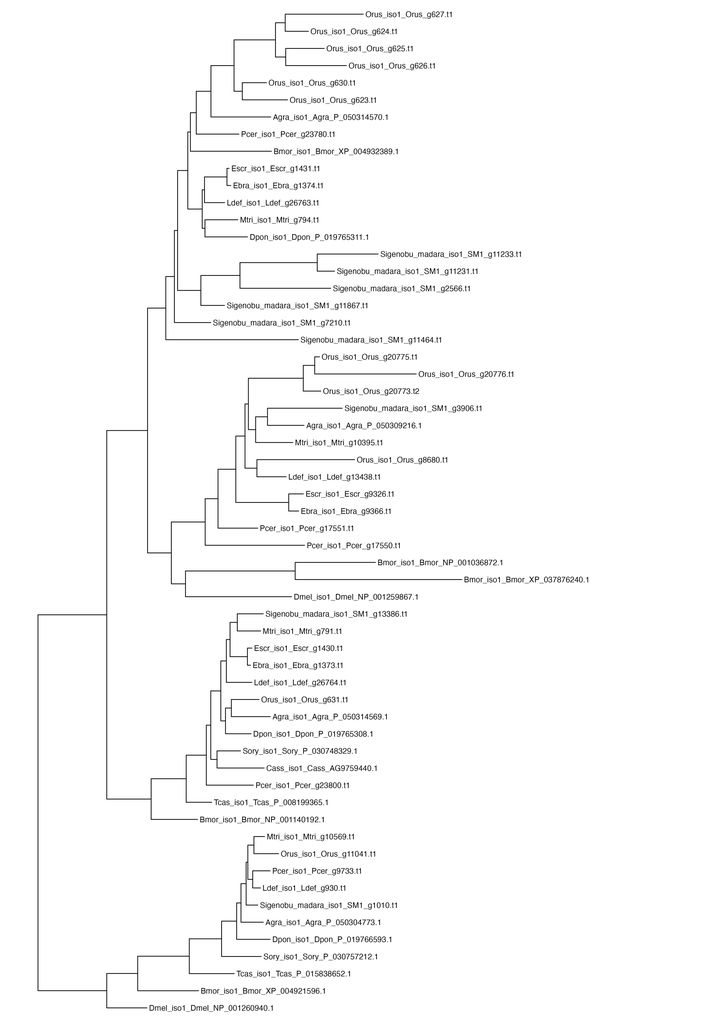

DEG・成虫と幼虫の比較

```bash
gene_ID adult.1 adult.2 adult.3 llarva.1    llarva.2    llarva.3    mlarva.1    mlarva.2    mlarva.3
g2209   186.4208519 28.2919987  40.59546851 4.973358757 4.660501324 3.559117856 4.576554877 3.714559078 2.192069084
```

成虫で高発現

DEG・卵巣と体細胞の比較

```bash
gene_ID body.1  body.2  body.3  ovary.1 ovary.2 ovary.3 seed_ortholog
g2209   4.855078896 4.219783968 4.872876757 8353.482036 6398.97959  259.7239617
```

卵巣でめちゃくちゃ高発現

### SM1_g328~330のゲノムブラウザ

SM1_g12995を解析した際に同じオーソログにまとめられた遺伝子たち。

[figure not shown]

## 1121

[Ren(2024)の論文](https://academic.oup.com/jinsectscience/article/24/4/25/7796689?login=true)だとオジロとEucryptorrhynchusが近縁で、leiosomaはより離れているとなっていた。  
しかし自分の系統樹ではEucryptorrhynchusとLeiosomaが近縁で、オジロはその外にいる。これはbraker2と3の違いか？2はdenovoのみでアノテーションするからバイアスがかかっているのか？

その検証のためオジロをRNA-seqデータなしでアノテーションしてみる。`~/tools/for_braker/251121_Ojiro_2_test`ディレクトリを作成、そこで以下のファイルを実行した。

```bash
### /home/kosukesano/tools/for_braker/251121_Ojiro_2_test/ojiro_braker.sh

#!/bin/bash
#SBATCH --job-name=ojiro_braker
#SBATCH -N 1-1
#SBATCH -n 32
#SBATCH --mem-per-cpu=8G
#SBATCH --partition=epyc
#SBATCH --error=/home/kosukesano/tools/for_braker/251121_Ojiro_2_test/log/%x_%j_%A_%a.err.log
#SBATCH --output=/home/kosukesano/tools/for_braker/251121_Ojiro_2_test/log/%x_%j_%A_%a.out.log
#SBATCH --time=120:00:00

#########YOUR JOB#############
echo start at
date

source /home/kosukesano/tools/pyenv_env/braker_profile_250602

braker.pl --genome=/home/kosukesano/tools/for_braker/nama_data/241226_ojiro_masked.fa\
        --prot_seq=/home/kosukesano/tools/Arthropoda.fa\
        --threads=32\
        --species=ojiro_2\
        --AUGUSTUS_CONFIG_PATH=/home/kosukesano/tools/config/AUGUSTUS_CONFIG_PATH/config\
        --AUGUSTUS_BIN_PATH=/usr/bin\
        --AUGUSTUS_SCRIPTS_PATH=/usr/share/augustus/scripts\
        --GENEMARK_PATH=/home/kosukesano/tools/GeneMarkETP_git_install/GeneMark-ETP/bin\
        --PROTHINT_PATH=/home/kosukesano/tools/ProtHint_git_install/ProtHint/bin\
        --TSEBRA_PATH=/home/kosukesano/tools/TSEBRA_git_install/TSEBRA/bin

echo end at
date
```

## 1126

### Molytinae系統樹作成のためのOrthoFinder

1121で作成したオジロのアノテーションとPstrを含めたゲノムでOrthoFinderを実行する

```bash
kosukesano@a001:~/tools/for_orthofinder/251126$ ls genome/
Agra_iso1.faa  Cass_iso1.faa  Dpon_iso1.faa  Escr_iso1.faa  Ojiro_2.faa    Pcer_iso1.faa  Sigenobu_madara_iso1.faa  Tcas_iso1.faa
Bmor_iso1.faa  Dmel_iso1.faa  Ebra_iso1.faa  Ldef_iso1.faa  Orus_iso1.faa  Pstr.faa       Sory_iso1.faa
kosukesano@a001:~/tools/for_orthofinder/251126$
```

### オジロゲノム中から植物ホルモン関連遺伝子を取得する

`~/tools/for_RBH/251126`ディレクトリを作成し、そこでオジロのゲノムDBを作成する

```bash
kosukesano@a001:~/tools/for_RBH/251126$ apptainer exec -e /usr/local/biotools/b/blast:2.9.0--pl526h979a64d_3 makeblastdb -in ~/tools/for_orthofinder/251114/genome/Mtri_iso1.faa -out Mtri_db -dbtype prot -hash_index
WARNING: Skipping mount /lustre10/software/apptainer/1.3.5/var/apptainer/mnt/session/etc/resolv.conf [files]: /etc/resolv.conf doesn't exist in container


Building a new DB, current time: 11/26/2025 14:06:37
New DB name:   /home/kosukesano/tools/for_RBH/251126/Mtri_db
New DB title:  /home/kosukesano/tools/for_orthofinder/251114/genome/Mtri_iso1.faa
Sequence type: Protein
Keep MBits: T
Maximum file size: 1000000000B
Adding sequences from FASTA; added 11600 sequences in 0.28879 seconds.
kosukesano@a001:~/tools/for_RBH/251126$ ls
Mtri_db.phd  Mtri_db.phi  Mtri_db.phr  Mtri_db.pin  Mtri_db.pog  Mtri_db.psd  Mtri_db.psi  Mtri_db.psq
kosukesano@a001:~/tools/for_RBH/251126$
```

**CK生合成遺伝子e2~e17の探索**

1003に行なった`blastp`の出力ファイルを参照する。以下のスクリプトをアレイジョブで実行した

```bash
### /home/kosukesano/tools/for_RBH/251126/CK_blastp.sh

#!/bin/bash
#SBATCH --job-name=CK_blastp
#SBATCH -n 2
#SBATCH --mem-per-cpu=4G
#SBATCH --partition=short
#SBATCH --error=/home/kosukesano/tools/for_RBH/251126/log/%x_%j_%A_%a.err.log
#SBATCH --output=/home/kosukesano/tools/for_RBH/251126/log/%x_%j_%A_%a.out.log
#SBATCH --time=1:00:00

#########YOUR JOB#############


echo starting at
date

#BLASTの標準列名を定義

header="qseqid sseqid pident length mismatch gapopen qstart qend sstart send evalue bitscore"

#出力ファイルの定義

output_file="e${SLURM_ARRAY_TASK_ID}_blastp.txt"

#列名を出力ファイルに書き込む

echo "$header" > $output_file

#BLASTpを実行し、結果を追加する

apptainer exec /usr/local/biotools/b/blast:2.9.0--pl526h979a64d_3 blastp \
-query /home/kosukesano/tools/for_RBH/251003/e${SLURM_ARRAY_TASK_ID}/uniprot_sequences.fasta \
-db /home/kosukesano/tools/for_RBH/251126/Mtri_db \
-evalue 1e-10 \
-num_threads 2 \
-outfmt 6 >> $output_file

echo ending at
date
```

**CK生合成遺伝子e1の探索**

e1のみ1002に行ったので、別途スクリプトを用意して実行

```bash
### /home/kosukesano/tools/for_RBH/251126/CK_e1_blastp.sh

#!/bin/bash
#SBATCH --job-name=CK_blastp
#SBATCH -n 2
#SBATCH --mem-per-cpu=4G
#SBATCH --partition=short
#SBATCH --error=/home/kosukesano/tools/for_RBH/251126/log/%x_%j_%A_%a.err.log
#SBATCH --output=/home/kosukesano/tools/for_RBH/251126/log/%x_%j_%A_%a.out.log
#SBATCH --time=1:00:00

#########YOUR JOB#############


echo starting at
date

#BLASTの標準列名を定義

header="qseqid sseqid pident length mismatch gapopen qstart qend sstart send evalue bitscore"

#出力ファイルの定義

output_file="e1_blastp.txt"

#列名を出力ファイルに書き込む

echo "$header" > $output_file

#BLASTpを実行し、結果を追加する

apptainer exec /usr/local/biotools/b/blast:2.9.0--pl526h979a64d_3 blastp \
-query /home/kosukesano/tools/for_RBH/251002/CK_e1_test/uniprot_sequences.fasta \
-db /home/kosukesano/tools/for_RBH/251126/Mtri_db \
-evalue 1e-10 \
-num_threads 2 \
-outfmt 6 >> $output_file

echo ending at
date
```

**IAA生合成関連遺伝子の取得**

1007に行なったBlastpの出力を参照する。以下のスクリプトを実行した。

```bash
### /home/kosukesano/tools/for_RBH/251126/IAA_blastp.sh

#!/bin/bash
#SBATCH --job-name=CK_blastp
#SBATCH -n 2
#SBATCH --mem-per-cpu=4G
#SBATCH --partition=short
#SBATCH --error=/home/kosukesano/tools/for_RBH/251126/log/%x_%j_%A_%a.err.log
#SBATCH --output=/home/kosukesano/tools/for_RBH/251126/log/%x_%j_%A_%a.out.log
#SBATCH --time=1:00:00

#########YOUR JOB#############


echo starting at
date

#BLASTの標準列名を定義

header="qseqid sseqid pident length mismatch gapopen qstart qend sstart send evalue bitscore"

#出力ファイルの定義

output_file="IAA_blastp.txt"

#列名を出力ファイルに書き込む

echo "$header" > $output_file

#BLASTpを実行し、結果を追加する

apptainer exec /usr/local/biotools/b/blast:2.9.0--pl526h979a64d_3 blastp \
-query /home/kosukesano/tools/for_RBH/251007/IAA_query.fasta \
-db /home/kosukesano/tools/for_RBH/251126/Mtri_db \
-evalue 1e-10 \
-num_threads 2 \
-outfmt 6 >> $output_file

echo ending at
date
```

### 結果｜オジロゲノムから検出されたCK・IAA関連遺伝子

#### e1

```bash
kosukesano@a001:~/tools/for_RBH/251126$ cut -f2 e1_blastp.txt | sort | uniq
Mtri_g2155.t2
qseqid sseqid pident length mismatch gapopen qstart qend sstart send evalue bitscore
kosukesano@a001:~/tools/for_RBH/251126$
```

- **Mtri_g2155.t2**

#### e2

```bash
kosukesano@a001:~/tools/for_RBH/251126$ cut -f2 e2_blastp.txt | sort | uniq
Mtri_g2155.t2
qseqid sseqid pident length mismatch gapopen qstart qend sstart send evalue bitscore
kosukesano@a001:~/tools/for_RBH/251126$
```

- **Mtri_g2155.t2**

#### e3

```bash
kosukesano@a001:~/tools/for_RBH/251126$ cut -f2 e3_blastp.txt | sort | uniq
Mtri_g1673.t1
qseqid sseqid pident length mismatch gapopen qstart qend sstart send evalue bitscore
kosukesano@a001:~/tools/for_RBH/251126$
```

- **Mtri_g1673.t1**

#### e4

```bash
kosukesano@a001:~/tools/for_RBH/251126$ cut -f2 e4_blastp.txt | sort | uniq
qseqid sseqid pident length mismatch gapopen qstart qend sstart send evalue bitscore
kosukesano@a001:~/tools/for_RBH/251126$
```

なし

#### e5

```bash
kosukesano@a001:~/tools/for_RBH/251126$ cut -f2 e5_blastp.txt | sort | uniq
Mtri_g1179.t1
Mtri_g1379.t3
Mtri_g1918.t1
Mtri_g2561.t1
Mtri_g4776.t1
Mtri_g784.t1
Mtri_g8690.t1
Mtri_g9052.t1
Mtri_g9362.t1
Mtri_g9493.t1
Mtri_g992.t1
qseqid sseqid pident length mismatch gapopen qstart qend sstart send evalue bitscore
kosukesano@a001:~/tools/for_RBH/251126$
```

- **Mtri_g1179.t1**
- **Mtri_g1379.t3**
- **Mtri_g1918.t1**
- **Mtri_g2561.t1**
- **Mtri_g4776.t1**
- **Mtri_g784.t1**
- **Mtri_g8690.t1**
- **Mtri_g9052.t1**
- **Mtri_g9362.t1**
- **Mtri_g9493.t1**
- **Mtri_g992.t1**

11この遺伝子が検出された

#### e6

```bash
kosukesano@a001:~/tools/for_RBH/251126$ cut -f2 e6_blastp.txt | sort | uniq
qseqid sseqid pident length mismatch gapopen qstart qend sstart send evalue bitscore
kosukesano@a001:~/tools/for_RBH/251126$
```

なし

#### e7

```bash
kosukesano@a001:~/tools/for_RBH/251126$ cut -f2 e7_blastp.txt | sort | uniq
Mtri_g2155.t2
qseqid sseqid pident length mismatch gapopen qstart qend sstart send evalue bitscore
kosukesano@a001:~/tools/for_RBH/251126$
```

- **Mtri_g2155.t2**

#### e8

```bash
kosukesano@a001:~/tools/for_RBH/251126$ cut -f2 e8_blastp.txt | sort | uniq
Mtri_g1752.t1
Mtri_g4210.t1
Mtri_g5367.t2
qseqid sseqid pident length mismatch gapopen qstart qend sstart send evalue bitscore
kosukesano@a001:~/tools/for_RBH/251126$
```

- **Mtri_g1752.t1**
- **Mtri_g4210.t1**
- **Mtri_g5367.t2**

#### e9

```bash
kosukesano@a001:~/tools/for_RBH/251126$ cut -f2 e9_blastp.txt | sort | uniq
Mtri_g1.t1
Mtri_g1024.t1
Mtri_g10707.t1
Mtri_g11593.t1
Mtri_g1519.t2
Mtri_g1907.t1
Mtri_g228.t1
Mtri_g3087.t1
Mtri_g3100.t1
Mtri_g3163.t1
Mtri_g3519.t1
Mtri_g3546.t1
Mtri_g4380.t1
Mtri_g4443.t1
Mtri_g5691.t1
Mtri_g5832.t1
Mtri_g5942.t2
Mtri_g6551.t1
Mtri_g6819.t1
Mtri_g6844.t1
Mtri_g6937.t1
Mtri_g7833.t1
Mtri_g7854.t1
Mtri_g7961.t2
Mtri_g8612.t1
Mtri_g8613.t1
Mtri_g8614.t1
Mtri_g8616.t1
Mtri_g8649.t1
Mtri_g8673.t1
Mtri_g8811.t1
Mtri_g9733.t1
qseqid sseqid pident length mismatch gapopen qstart qend sstart send evalue bitscore
kosukesano@a001:~/tools/for_RBH/251126$
```

- **Mtri_g1.t1**
- **Mtri_g1024.t1**
- **Mtri_g10707.t1**
- **Mtri_g11593.t1**
- **Mtri_g1519.t2**
- **Mtri_g1907.t1**
- **Mtri_g228.t1**
- **Mtri_g3087.t1**
- **Mtri_g3100.t1**
- **Mtri_g3163.t1**
- **Mtri_g3519.t1**
- **Mtri_g3546.t1**
- **Mtri_g4380.t1**
- **Mtri_g4443.t1**
- **Mtri_g5691.t1**
- **Mtri_g5832.t1**
- **Mtri_g5942.t2**
- **Mtri_g6551.t1**
- **Mtri_g6819.t1**
- **Mtri_g6844.t1**
- **Mtri_g6937.t1**
- **Mtri_g7833.t1**
- **Mtri_g7854.t1**
- **Mtri_g7961.t2**
- **Mtri_g8612.t1**
- **Mtri_g8613.t1**
- **Mtri_g8614.t1**
- **Mtri_g8616.t1**
- **Mtri_g8649.t1**
- **Mtri_g8673.t1**
- **Mtri_g8811.t1**
- **Mtri_g9733.t1**

#### e10

```bash
kosukesano@a001:~/tools/for_RBH/251126$ cut -f2 e10_blastp.txt | sort | uniq
Mtri_g6035.t1
qseqid sseqid pident length mismatch gapopen qstart qend sstart send evalue bitscore
kosukesano@a001:~/tools/for_RBH/251126$
```

- **Mtri_g6035.t1**

#### e11

```bash
kosukesano@a001:~/tools/for_RBH/251126$ cut -f2 e11_blastp.txt | sort | uniq
qseqid sseqid pident length mismatch gapopen qstart qend sstart send evalue bitscore
kosukesano@a001:~/tools/for_RBH/251126$
```

なし

#### e12

```bash
kosukesano@a001:~/tools/for_RBH/251126$ cut -f2 e12_blastp.txt | sort | uniq
Mtri_g10526.t1
Mtri_g10527.t1
Mtri_g10528.t1
Mtri_g10529.t1
Mtri_g10869.t1
Mtri_g10870.t1
Mtri_g10871.t1
Mtri_g1211.t2
Mtri_g1213.t1
Mtri_g2132.t1
Mtri_g2133.t1
Mtri_g4897.t2
qseqid sseqid pident length mismatch gapopen qstart qend sstart send evalue bitscore
kosukesano@a001:~/tools/for_RBH/251126$
```

#### e13

```bash
kosukesano@a001:~/tools/for_RBH/251126$ cut -f2 e13_blastp.txt | sort | uniq
Mtri_g10527.t1
Mtri_g10529.t1
Mtri_g10870.t1
Mtri_g4897.t2
qseqid sseqid pident length mismatch gapopen qstart qend sstart send evalue bitscore
kosukesano@a001:~/tools/for_RBH/251126$
```

#### e14~e17

```bash
kosukesano@a001:~/tools/for_RBH/251126$ cut -f2 e14_blastp.txt | sort | uniq
qseqid sseqid pident length mismatch gapopen qstart qend sstart send evalue bitscore
kosukesano@a001:~/tools/for_RBH/251126$ cut -f2 e15_blastp.txt | sort | uniq
qseqid sseqid pident length mismatch gapopen qstart qend sstart send evalue bitscore
kosukesano@a001:~/tools/for_RBH/251126$ cut -f2 e15_blastp.txt | sort | uniq
qseqid sseqid pident length mismatch gapopen qstart qend sstart send evalue bitscore
kosukesano@a001:~/tools/for_RBH/251126$ cut -f2 e16_blastp.txt | sort | uniq
qseqid sseqid pident length mismatch gapopen qstart qend sstart send evalue bitscore
kosukesano@a001:~/tools/for_RBH/251126$ cut -f2 e17_blastp.txt | sort | uniq
qseqid sseqid pident length mismatch gapopen qstart qend sstart send evalue bitscore
kosukesano@a001:~/tools/for_RBH/251126$
```

#### IAA関連遺伝子

```bash
qseqid sseqid pident length mismatch gapopen qstart qend sstart send evalue bitscore
XP_004925960.2  Mtri_g8046.t1   41.124  1245    685 24  1   1225    6   1222    0.0 898
XP_004925960.2  Mtri_g1739.t1   40.157  1275    720 21  2   1255    5   1257    0.0 885
XP_004925960.2  Mtri_g5838.t1   29.888  1335    799 31  25  1252    34  1338    6.23e-155   499
XP_004925960.2  Mtri_g5839.t6   29.351  1356    813 37  6   1252    37  1356    3.31e-145   474
XP_004925960.2  Mtri_g5840.t2   29.602  1054    662 24  253 1247    333 1365    5.74e-125   418
XP_004925960.2  Mtri_g5840.t2   42.500  160 87  2   6   161 19  177 8.20e-28    121
CAD55403.1  Mtri_g5062.t2   21.558  385 219 11  17  390 38  350 1.90e-22    97.8
CAD55403.1  Mtri_g5060.t1   31.088  193 121 5   23  206 23  212 4.50e-21    93.6
CAD55403.1  Mtri_g5060.t1   31.683  101 64  3   296 393 237 335 2.46e-14    73.2
NP_001324415.1  Mtri_g6637.t1   43.093  485 228 8   12  461 1   472 4.70e-128   379
NP_001324415.1  Mtri_g6640.t2   43.121  487 226 7   12  461 5   477 2.55e-123   367
NP_001324415.1  Mtri_g8772.t1   40.854  492 235 10  12  461 1   478 5.86e-121   364
NP_001324415.1  Mtri_g5417.t1   37.832  489 253 7   12  463 1   475 5.47e-111   341
NP_001324415.1  Mtri_g6638.t1   34.647  482 270 8   12  461 1   469 1.80e-94    293
NP_001324415.1  Mtri_g8771.t1   38.372  258 122 4   232 461 1   249 2.54e-48    167
NP_001324415.1  Mtri_g8127.t1   23.575  386 256 6   40  394 88  465 2.99e-27    113
NP_001324415.1  Mtri_g10953.t1  22.462  325 215 4   99  394 95  411 1.80e-21    95.9
```

### 植物ホルモン関連遺伝子のDEG

```bash
Mt_PH=readr::read_csv("/Users/kosukesano/Desktop/牧野研_10セメ/オジロ論文/植物ホルモン関連/オジロ植物ホルモン遺伝子まとめ.csv")|>
  dplyr::select(c(1, 2)) |>
  dplyr::mutate(Mtri_ID=stringr::str_replace(Mtri_ID, "Mtri_", ""))|>
  print()
Mt_DEG=readr::read_csv("/Users/kosukesano/Desktop/genome_data/241226_Ojiro_braker/DEG/Ojiro_Stage_Part_DEG.csv")|>
  dplyr::rename(Mtri_ID=transcript_ID)|>
  dplyr::right_join(Mt_PH, by="Mtri_ID")|>
  dplyr::filter(gene_no == "e1")|>
  print()
Mt_TPM=readr::read_csv("/Users/kosukesano/bio/for_paml/250810/TPM_table.csv")|>
  dplyr::rename(Mtri_ID=transcript_ID)|>
  dplyr::right_join(Mt_DEG, by="Mtri_ID")|>
  print()
```

#### e1

```bash
  stage_deg Mtri_ID  part_deg gene_no
  <chr>     <chr>    <chr>    <chr>
1 L>E>A     g2155.t2 O>T>H    e1
```

#### e2

```bash
  stage_deg Mtri_ID  part_deg gene_no
  <chr>     <chr>    <chr>    <chr>
1 L>E>A     g2155.t2 O>T>H    e2
```

#### e3

```bash
  stage_deg Mtri_ID  part_deg gene_no
  <chr>     <chr>    <chr>    <chr>
1 NA        g1673.t1 O>H>T    e3
```

#### e5

```bash
   stage_deg Mtri_ID  part_deg gene_no
   <chr>     <chr>    <chr>    <chr>
 1 E>L>A     g1179.t1 T>H>O    e5
 2 E>L>A     g1379.t3 NA       e5
 3 A>L>E     g1918.t1 NA       e5
 4 L>A>E     g4776.t1 T>H>O    e5
 5 A>E>L     g784.t1  O>H>T    e5
 6 L>A>E     g8690.t1 O>T>H    e5
 7 L>A>E     g9362.t1 T>H>O    e5
 8 A>L>E     g992.t1  O>H>T    e5
 9 NA        g2561.t1 O>H>T    e5
10 NA        g9052.t1 O>H>T    e5
11 NA        g9493.t1 O>H>T    e5
```

#### e7

```bash
  stage_deg Mtri_ID  part_deg gene_no
  <chr>     <chr>    <chr>    <chr>
1 L>E>A     g2155.t2 O>T>H    e7
```

#### e8

```bash
  stage_deg Mtri_ID  part_deg gene_no
  <chr>     <chr>    <chr>    <chr>
1 L>E>A     g1752.t1 T>H>O    e8
2 NA        g4210.t1 T>H>O    e8
3 NA        g5367.t2 T>O>H    e8
```

#### e9

```bash
   stage_deg Mtri_ID   part_deg gene_no
   <chr>     <chr>     <chr>    <chr>
 1 L>E>A     g10707.t1 T>H>O    e9
 2 A>E>L     g1907.t1  NA       e9
 3 E>L>A     g228.t1   O>H>T    e9
 4 E>A>L     g3087.t1  O>H>T    e9
 5 E>L>A     g3546.t1  T>O>H    e9
 6 A>L>E     g5691.t1  O>H>T    e9
 7 A>L>E     g5832.t1  T>H>O    e9
 8 E>A>L     g6819.t1  O>H>T    e9
 9 L>A>E     g7854.t1  T>H>O    e9
10 L>A>E     g8612.t1  T>H>O    e9
11 E>L>A     g8613.t1  H>O>T    e9
12 L>A>E     g8616.t1  T>O>H    e9
13 A>L>E     g8649.t1  NA       e9
14 L>A>E     g8811.t1  T>O>H    e9
15 NA        g11593.t1 T>H>O    e9
16 NA        g1519.t2  T>H>O    e9
17 NA        g1.t1     O>H>T    e9
18 NA        g3100.t1  O>T>H    e9
19 NA        g3163.t1  O>H>T    e9
20 NA        g3519.t1  O>H>T    e9
21 NA        g4380.t1  O>T>H    e9
22 NA        g4443.t1  O>H>T    e9
23 NA        g5942.t2  O>H>T    e9
24 NA        g6551.t1  O>H>T    e9
25 NA        g6844.t1  O>H>T    e9
26 NA        g6937.t1  O>H>T    e9
27 NA        g7961.t2  O>H>T    e9
28 NA        g8673.t1  O>H>T    e9
29 NA        g9733.t1  T>H>O    e9
30 NA        g1024.t1  NA       e9
31 NA        g7833.t1  NA       e9
32 NA        g8614.t1  NA       e9
```

#### e10

```bash
  stage_deg Mtri_ID  part_deg gene_no
  <chr>     <chr>    <chr>    <chr>
1 NA        g6035.t1 T>O>H    e10
```

#### e12

```bash
   stage_deg Mtri_ID   part_deg gene_no
   <chr>     <chr>     <chr>    <chr>
 1 L>A>E     g10526.t1 T>H>O    e12
 2 L>E>A     g10870.t1 T>H>O    e12
 3 A>E>L     g10871.t1 H>T>O    e12
 4 L>E>A     g1211.t2  T>H>O    e12
 5 A>L>E     g1213.t1  H>T>O    e12
 6 L>A>E     g2133.t1  NA       e12
 7 L>E>A     g4897.t2  T>H>O    e12
 8 NA        g10869.t1 H>T>O    e12
 9 NA        g2132.t1  T>O>H    e12
10 NA        g10527.t1 NA       e12
11 NA        g10528.t1 NA       e12
12 NA        g10529.t1 NA       e12
```

#### BMIAO1

```bash
  stage_deg Mtri_ID  part_deg gene_no
  <chr>     <chr>    <chr>    <chr>
1 L>A>E     g5839.t6 T>H>O    BMIAO1
2 A>E>L     g5840.t2 T>H>O    BMIAO1
3 NA        g1739.t1 H>T>O    BMIAO1
4 NA        g5838.t1 T>H>O    BMIAO1
5 NA        g8046.t1 T>H>O    BMIAO1
```

#### FMO

```bash
  <chr>     <chr>    <chr>    <chr>
1 L>E>A     g5060.t1 NA       FMO
2 L>A>E     g5062.t2 T>H>O    FMO
```

#### AAS

```bash
  stage_deg Mtri_ID   part_deg gene_no
  <chr>     <chr>     <chr>    <chr>
1 L>E>A     g6638.t1  NA       AAS
2 L>E>A     g6640.t2  H>T>O    AAS
3 L>E>A     g8127.t1  H>O>T    AAS
4 NA        g10953.t1 H>T>O    AAS
5 NA        g5417.t1  H>O>T    AAS
6 NA        g6637.t1  H>T>O    AAS
7 NA        g8771.t1  O>H>T    AAS
8 NA        g8772.t1  H>O>T    AAS
```

### 遺伝研メモリ使用量チェック

```bash
#!/bin/bash
#SBATCH --job-name=memory_test
#SBATCH -n 1
#SBATCH --mem-per-cpu=1G
#SBATCH --partition=epyc
#SBATCH --error=/home/kosukesano/log/%x_%j_%A_%a.err.log
#SBATCH --output=/home/kosukesano/log/%x_%j_%A_%a.out.log
#SBATCH --time=120:00:00

#########YOUR JOB#############


du -h /home/kosukesano/ | sort -h | tail -n 100>memory_max100.txt
```

## 1127

### Pstrのマスキングやり直し

RepeatModelerのDBとDfamのDBを統合する方法でPstrのマスキングをやり直す。

RepeatModelerはすでに行なっていたので、出力を流用する

```bash
kosukesano@a001:~/tools/for_braker/250829_Lmin$ ls ~/tools/for_softmask/Pstr_softmask
Pstr_BLAST_DATABASE_PREFIX-families.fa   Pstr_BLAST_DATABASE_PREFIX.nnd          Pstr_RepeatMasker.sh             Pstr_RepeatModeler.sh             RM_77685.SunSep222227102024
Pstr_BLAST_DATABASE_PREFIX-families.stk  Pstr_BLAST_DATABASE_PREFIX.nni          Pstr_RepeatMasker.sh.e26901739   Pstr_RepeatModeler.sh.e26802487
Pstr_BLAST_DATABASE_PREFIX.nhr           Pstr_BLAST_DATABASE_PREFIX.nog          Pstr_RepeatMasker.sh.o26901739   Pstr_RepeatModeler.sh.o26802487
Pstr_BLAST_DATABASE_PREFIX.nin           Pstr_BLAST_DATABASE_PREFIX.nsq          Pstr_RepeatMasker.sh.pe26901739  Pstr_RepeatModeler.sh.pe26802487
Pstr_BLAST_DATABASE_PREFIX.njs           Pstr_BLAST_DATABASE_PREFIX.translation  Pstr_RepeatMasker.sh.po26901739  Pstr_RepeatModeler.sh.po26802487
kosukesano@a001:~/tools/for_braker/250829_Lmin$ ls ~/tools/for_softmask/Pstr_softmask/RM_77685.SunSep222227102024/
consensi.fa  consensi.fa.classified  families-classified.stk  families.stk  round-1  round-2  round-3  round-4  round-5  round-6  tmpConsensi.fa
kosukesano@a001:~/tools/for_braker/250829_Lmin$
```

このconsensi.fa.classifiedとDfamのDBをくっつける

```bash
kosukesano@a001:~/tools/for_RepeatMasker_Docker/nama_data$ cat Dfam-RepeatMasker.lib ~/tools/for_softmask/Pstr_softmask/RM_77685.SunSep222227102024/consensi.fa.classified > 251127_for_Pstr.lib
kosukesano@a001:~/tools/for_RepeatMasker_Docker/nama_data$ ls
231117_madaragenome.fasta  241220_for_ojiro.lib  250617_for_Orus.lib  250618_for_Ebra.lib  251127_for_Pstr.lib  Dfam-RepeatMasker.lib  Lmin_ncbi_dataset.zip  md5sum.txt
241128_for_madara.lib      250617_for_Ldef.lib   250617_for_Pcer.lib  250618_for_Escr.lib  Ccar                 Lmin                   README.md
kosukesano@a001:~/tools/for_RepeatMasker_Docker/nama_data$
```

これを使ってRepeatMaskerを実行する

```bash
### /home/kosukesano/tools/for_RepeatMasker_Docker/251127_Pstr/Pstr_softmask.sh

#!/bin/bash
#SBATCH --job-name=Pstr_RepeatMasker
#SBATCH -n 32
#SBATCH --mem-per-cpu=8G
#SBATCH --partition=epyc
#SBATCH --error=/home/kosukesano/tools/for_RepeatMasker_Docker/251127_Pstr/log/%x_%j_%A_%a.err.log
#SBATCH --output=/home/kosukesano/tools/for_RepeatMasker_Docker/251127_Pstr/log/%x_%j_%A_%a.out.log
#SBATCH --time=120:00:00

#########YOUR JOB#############

echo start at
date

apptainer exec /home/kosukesano/tools/for_RepeatMasker_Docker/dfam-tetools_1.sif\
        RepeatMasker\
        -pa 32\
        -s\
        -lib /home/kosukesano/tools/for_RepeatMasker_Docker/nama_data/251127_for_Pstr.lib\
        -dir /home/kosukesano/tools/for_RepeatMasker_Docker/251127_Pstr/output_dir\
        -xsmall\
        -gff\
        /home/kosukesano/tools/for_softmask/nama_data/Pstr_data/GCA_016904865.1/GCA_016904865.1_GSC_weevil_1.0_genomic.fna


echo end at
date
```

### オジロ論文用の作図

`/Users/kosukesano/bio/251127_Ojiro_ronbun`ディレクトリを用意し、そこでRstudio環境を立ち上げた。  
その下の`/Users/kosukesano/bio/251127_Ojiro_ronbun/オジロ作図.R`ファイルで作図スクリプトを検証中

```bash
### /Users/kosukesano/bio/251127_Ojiro_ronbun/オジロ作図.R

library(tidyverse)
library(patchwork)

install.packages("remotes")
library(remotes)

remotes::install_github("YuLab-SMU/ggmsa")

#install.packages("ggmsa")
library(ggmsa)

library(ape)
library(ggtree)

#install.packages("arrow")
library(arrow)

###############################################################################
### 251127


Mt_PH=arrow::read_csv_arrow("/Users/kosukesano/Desktop/牧野研_10セメ/オジロ論文/植物ホルモン関連/オジロ植物ホルモン遺伝子まとめ.csv")|>
  dplyr::select(c(1, 2)) |>
  dplyr::mutate(Mtri_ID=stringr::str_replace(Mtri_ID, "Mtri_", ""))|>
  print()
Mt_DEG=arrow::read_csv_arrow("/Users/kosukesano/Desktop/genome_data/241226_Ojiro_braker/DEG/Ojiro_Stage_Part_DEG.csv")|>
  dplyr::rename(Mtri_ID=transcript_ID)|>
  dplyr::right_join(Mt_PH, by="Mtri_ID")|>
  #dplyr::filter(gene_no == "AAS")|>
  #print(n = 32)
  print()
Mt_TPM=arrow::read_csv_arrow("/Users/kosukesano/bio/for_paml/250810/TPM_table.csv")|>
  dplyr::rename(Mtri_ID=transcript_ID)|>
  dplyr::right_join(Mt_DEG, by="Mtri_ID")|>
  print()
View(Mt_TPM)

## DEG可視化テスト

DF_test=Mt_TPM|>
  dplyr::filter(gene_no == "FMO")|>
  dplyr::select(1:22)|>
  pivot_longer(3:22, names_to="deg", values_to="value")|>
  tidyr::separate(deg, into = c("sp_name", "deg"), sep = "_")|>
  tidyr::separate(deg, into = c("deg", "number"), sep = 1L)|>
  dplyr::mutate(deg=stringr::str_replace(deg, "H", "A"))|>
  dplyr::mutate(deg=stringr::str_replace(deg, "T", "A"))|>
  dplyr::mutate(deg=stringr::str_replace(deg, "O", "A"))|>
  #tidyr::unite(gene_deg, gene_ID, deg, sep = "_") |>
  #dplyr::group_by(gene_deg) |>
  #dplyr::summarize(avg_value = mean(value)) |>
  dplyr::filter(Mtri_ID == "g5060.t1")|>
  dplyr::group_by(deg) |>
  dplyr::mutate(deg=factor(deg, levels= c("E", "L", "A")))|>
  print()

ggplot(data=DF_test)+
  aes(x=deg, y=value)+
  geom_boxplot()+
  geom_jitter(width=0.2)+
  #geom_point()+
  theme_classic(base_size = 20)
```

### 結果｜遺伝研メモリチェック

```bash
#!/bin/bash
#SBATCH --job-name=memory_test
#SBATCH -n 1
#SBATCH --mem-per-cpu=1G
#SBATCH --partition=epyc
#SBATCH --error=/home/kosukesano/log/%x_%j_%A_%a.err.log
#SBATCH --output=/home/kosukesano/log/%x_%j_%A_%a.out.log
#SBATCH --time=120:00:00

#########YOUR JOB#############


du -h --max-depth=5 /home/kosukesano/ | sort -h | tail -n 100 > memory_max100.txt
```

これを実行した

結果はこう

```bash
14G /home/kosukesano/tools/for_brakertest/share_of_augustus/braker/GeneMark-EP
15G /home/kosukesano/.pyenv/versions/mambaforge-22.9.0-3
16G /home/kosukesano/.apptainer
16G /home/kosukesano/.apptainer/cache
16G /home/kosukesano/tools/for_braker/Kohuki/braker/GeneMark-ES
17G /home/kosukesano/old_envilonment_until20240430/leaf_beetle/other_genome
17G /home/kosukesano/tools/for_braker/Pstr/braker/GeneMark-EP
17G /home/kosukesano/tools/for_brakertest/share_of_augustus/braker/GeneMark-ES
18G /home/kosukesano/old_envilonment_until20240430/EDTA
18G /home/kosukesano/tools/for_SignalP
19G /home/kosukesano/tools/for_ginger/250123_test
19G /home/kosukesano/tools/for_ginger/250123_test/nama_data
20G /home/kosukesano/.anaconda_backup/2024-04-30T110900/.conda/envs/EDTA
20G /home/kosukesano/tools/for_braker/Kohuki_thread_one
20G /home/kosukesano/tools/for_braker/Kohuki_thread_one/braker
20G /home/kosukesano/tools/for_orthofinder/250825
21G /home/kosukesano/.anaconda_backup/2024-04-30T110900/.conda/envs
21G /home/kosukesano/tools/for_braker/Pstr/braker/GeneMark-ES
23G /home/kosukesano/.anaconda_backup
23G /home/kosukesano/.anaconda_backup/2024-04-30T110900
23G /home/kosukesano/.anaconda_backup/2024-04-30T110900/.conda
25G /home/kosukesano/old_envilonment_until20240430/leaf_beetle/femo_genome
25G /home/kosukesano/tools/for_gemoma/241203_test
25G /home/kosukesano/tools/for_gemoma/241203_test/GeMoMa_temp
25G /home/kosukesano/tools/for_gemoma/nama_data
26G /home/kosukesano/tools/for_braker/Kohuki/braker
26G /home/kosukesano/tools/for_braker/Kohuki/upper1k
26G /home/kosukesano/tools/for_braker/Kohuki/upper1k/braker
26G /home/kosukesano/tools/for_ginger
38G /home/kosukesano/tools/for_brakertest/share_of_augustus/braker
39G /home/kosukesano/tools/for_braker/250602_madara_test/braker/GeneMark-ETP
39G /home/kosukesano/tools/for_braker/250602_madara_test/braker_result_250602/GeneMark-ETP
39G /home/kosukesano/tools/for_braker/250602_madara_test/braker_result_250604/GeneMark-ETP
39G /home/kosukesano/tools/for_braker/250604_madara_memory_test/braker/GeneMark-ETP
39G /home/kosukesano/tools/for_softmask/kohuki_softmask
43G /home/kosukesano/old_envilonment_until20240430/leaf_beetle
44G /home/kosukesano/tools/for_softmask/250121_Kohuki_softmask/busco_out
44G /home/kosukesano/tools/for_softmask/250121_Kohuki_softmask/busco_out/run_endopterygota_odb10
48G /home/kosukesano/tools/for_brakertest/share_of_augustus/rnaplus_output_test/changed_id_test_rna
50G /home/kosukesano/tools/for_braker/Pstr/braker
51G /home/kosukesano/tools/for_RepeatMasker_Docker
51G /home/kosukesano/tools/for_braker/Pstr/upper_10_k
51G /home/kosukesano/tools/for_braker/Pstr/upper_10_k/braker
52G /home/kosukesano/tools/for_braker/Kohuki
52G /home/kosukesano/tools/for_braker/Pstr/upper_5_k
52G /home/kosukesano/tools/for_braker/Pstr/upper_5_k/braker
53G /home/kosukesano/tools/for_orthofinder
54G /home/kosukesano/tools/for_braker/Pstr/upper_1_k
54G /home/kosukesano/tools/for_braker/Pstr/upper_1_k/braker
60G /home/kosukesano/tools/for_gemoma
61G /home/kosukesano/tools/for_EggNogMapper
61G /home/kosukesano/tools/for_EggNogMapper/DB
66G /home/kosukesano/tools/for_softmask/250121_Kohuki_softmask
71G /home/kosukesano/tools/for_braker/250916_Kohuki/braker/GeneMark-ETP
72G /home/kosukesano/tools/for_braker/250204_Kohuki/braker/GeneMark-ETP
75G /home/kosukesano/tools/for_panther/target
75G /home/kosukesano/tools/for_panther/target/famlib
75G /home/kosukesano/tools/for_panther/target/famlib/rel
84G /home/kosukesano/old_envilonment_until20240430
92G /home/kosukesano/tools/for_panther
112G    /home/kosukesano/tools/for_softmask/nama_data/Release_241005-ojiro_hifiasm
153G    /home/kosukesano/tools/for_softmask/nama_data
169G    /home/kosukesano/.pyenv/versions/mambaforge-23.11.0-0/envs/EarlGrey
181G    /home/kosukesano/.pyenv/versions/mambaforge-23.11.0-0/envs
194G    /home/kosukesano/.pyenv/versions/mambaforge-23.11.0-0
206G    /home/kosukesano/tools/for_braker/Pstr
207G    /home/kosukesano/tools/for_braker/nama_data/Kohuki_RNAseq
207G    /home/kosukesano/tools/for_braker/nama_data/Kohuki_RNAseq/kaitou
229G    /home/kosukesano/.pyenv
229G    /home/kosukesano/.pyenv/versions
238G    /home/kosukesano/tools/for_braker/250602_madara_test/braker/rnaseq
238G    /home/kosukesano/tools/for_braker/250602_madara_test/braker_result_250602/rnaseq
238G    /home/kosukesano/tools/for_braker/250602_madara_test/braker_result_250604/rnaseq
238G    /home/kosukesano/tools/for_braker/250604_madara_memory_test/braker/rnaseq
257G    /home/kosukesano/tools/for_braker/nama_data/Madara_RNAseq
257G    /home/kosukesano/tools/for_brakertest/share_of_augustus/rnaplus_output_test/RNA
282G    /home/kosukesano/tools/for_braker/250602_madara_test/braker
282G    /home/kosukesano/tools/for_braker/250602_madara_test/braker_result_250602
282G    /home/kosukesano/tools/for_braker/250602_madara_test/braker_result_250604
282G    /home/kosukesano/tools/for_braker/250604_madara_memory_test/braker
282G    /home/kosukesano/tools/for_braker/250604_madara_memory_test/epyc_test
282G    /home/kosukesano/tools/for_braker/250604_madara_memory_test/epyc_test/braker
307G    /home/kosukesano/tools/for_brakertest/share_of_augustus/rnaplus_output_test
321G    /home/kosukesano/tools/for_braker/nama_data/Sfem_RNAseq
346G    /home/kosukesano/tools/for_brakertest
346G    /home/kosukesano/tools/for_brakertest/share_of_augustus
349G    /home/kosukesano/tools/for_softmask
402G    /home/kosukesano/tools/for_braker/nama_data/Ojiro_RNAseq
563G    /home/kosukesano/tools/for_braker/250604_madara_memory_test
658G    /home/kosukesano/tools/for_braker/250204_Kohuki/braker/rnaseq
658G    /home/kosukesano/tools/for_braker/250916_Kohuki/braker/rnaseq
734G    /home/kosukesano/tools/for_braker/250916_Kohuki
734G    /home/kosukesano/tools/for_braker/250916_Kohuki/braker
736G    /home/kosukesano/tools/for_braker/250204_Kohuki
736G    /home/kosukesano/tools/for_braker/250204_Kohuki/braker
844G    /home/kosukesano/tools/for_braker/250602_madara_test
1.3T    /home/kosukesano/tools/for_braker/nama_data
4.4T    /home/kosukesano/tools/for_braker
5.5T    /home/kosukesano/tools
5.8T    /home/kosukesano/
```

BRAKER周りが結構重いのか……。

## 1128

### クチカクシゾウムシのゲノムをマスキングする

[Haran, 2023](https://royalsocietypublishing.org/doi/full/10.1098/rspb.2023.0889)の論文だとクチカクシゾウムシのCryptorhynchusがMolytinaeに含まれてるっぽい。ncbiのゾウムシゲノムのうち、クチカクシゾウムシと思われる3種にアノテーションをつける。

- *Cryptorhynchus lapathi*
  - Clap
  - マダラクチカクシゾウムシ
  - [ゲノムデータ](https://www.ncbi.nlm.nih.gov/datasets/genome/GCA_965641385.1/)
- *Sternochetus mangiferae*
  - Sman
  - マンゴークチカクシゾウムシ？
  - [ゲノムデータ](https://www.ncbi.nlm.nih.gov/datasets/genome/GCA_051294475.1/)
- *Kyklioacalles roboris*
  - Krob
  - クチカクシゾウムシsp.
  - [ゲノムデータ](https://www.ncbi.nlm.nih.gov/datasets/genome/GCA_964211925.1/)

```bash
kosukesano@a001:~/tools/for_RepeatMasker_Docker/nama_data$ ls
231117_madaragenome.fasta  250617_for_Orus.lib  251127_for_Pstr.lib                      Dfam-RepeatMasker.lib  Sman
241128_for_madara.lib      250617_for_Pcer.lib  Ccar                                     Lmin                   Sternochetus_mangiferae_ncbi_dataset.zip
241220_for_ojiro.lib       250618_for_Ebra.lib  Clap                                     Lmin_ncbi_dataset.zip  md5sum.txt
250617_for_Ldef.lib        250618_for_Escr.lib  Cryptorhynchus_lapathi_ncbi_dataset.zip  README.md
kosukesano@a001:~/tools/for_RepeatMasker_Docker/nama_data$ ls Sman/ncbi_dataset/data/GCA_051294475.1/
GCA_051294475.1_ASM5129447v1_genomic.fna  genomic.gbff                              sequence_report.jsonl
kosukesano@a001:~/tools/for_RepeatMasker_Docker/nama_data$ ls Sman/ncbi_dataset/data/GCA_051294475.1/
GCA_051294475.1_ASM5129447v1_genomic.fna  genomic.gbff  sequence_report.jsonl
kosukesano@a001:~/tools/for_RepeatMasker_Docker/nama_data$ ls
231117_madaragenome.fasta  250617_for_Orus.lib  251127_for_Pstr.lib                      Dfam-RepeatMasker.lib                   README.md
241128_for_madara.lib      250617_for_Pcer.lib  Ccar                                     Kyklioacalles_roboris_ncbi_dataset.zip  Sman
241220_for_ojiro.lib       250618_for_Ebra.lib  Clap                                     Lmin                                    Sternochetus_mangiferae_ncbi_dataset.zip
250617_for_Ldef.lib        250618_for_Escr.lib  Cryptorhynchus_lapathi_ncbi_dataset.zip  Lmin_ncbi_dataset.zip                   md5sum.txt
kosukesano@a001:~/tools/for_RepeatMasker_Docker/nama_data$ unzip Kyklioacalles_roboris_ncbi_dataset.zip -d Krob
Archive:  Kyklioacalles_roboris_ncbi_dataset.zip
  inflating: Krob/README.md
  inflating: Krob/ncbi_dataset/data/data_summary.tsv
  inflating: Krob/ncbi_dataset/data/assembly_data_report.jsonl
  inflating: Krob/ncbi_dataset/data/GCA_964211925.1/genomic.gbff
  inflating: Krob/ncbi_dataset/data/GCA_964211925.1/GCA_964211925.1_icKykRobo1.hap1.1_genomic.fna
  inflating: Krob/ncbi_dataset/data/GCA_964211925.1/sequence_report.jsonl
  inflating: Krob/ncbi_dataset/data/dataset_catalog.json
  inflating: Krob/md5sum.txt
kosukesano@a001:~/tools/for_RepeatMasker_Docker/nama_data$ ls
231117_madaragenome.fasta  250617_for_Orus.lib  251127_for_Pstr.lib                      Dfam-RepeatMasker.lib                   Lmin_ncbi_dataset.zip                     md5sum.txt
241128_for_madara.lib      250617_for_Pcer.lib  Ccar                                     Krob                                    README.md
241220_for_ojiro.lib       250618_for_Ebra.lib  Clap                                     Kyklioacalles_roboris_ncbi_dataset.zip  Sman
250617_for_Ldef.lib        250618_for_Escr.lib  Cryptorhynchus_lapathi_ncbi_dataset.zip  Lmin                                    Sternochetus_mangiferae_ncbi_dataset.zip
kosukesano@a001:~/tools/for_RepeatMasker_Docker/nama_data$
```

#### Clap

まず環境を立ち上げる

```bash
kosukesano@a001:~/tools/for_RepeatMasker_Docker/nama_data$ source ~/tools/pyenv_env/EDTA_profile_250609
(EDTA) kosukesano@a001:~/tools/for_RepeatMasker_Docker/nama_data$
```

次に`~/tools/for_RepeatMasker_Docker/251128/Clap`ディレクトリを作成し、データベース構築

```bash
(EDTA) kosukesano@a001:~/tools/for_RepeatMasker_Docker/251128/Clap$ BuildDatabase -name Clap_DATABASE ../../nama_data/Clap/data/GCA_965641385.1/GCA_965641385.1_icCryLapa1.hap1.1_genomic.fna
Building database Clap_DATABASE:
  Reading ../../nama_data/Clap/data/GCA_965641385.1/GCA_965641385.1_icCryLapa1.hap1.1_genomic.fna...
Number of sequences (bp) added to database: 178 ( 478904227 bp )
(EDTA) kosukesano@a001:~/tools/for_RepeatMasker_Docker/251128/Clap$ ls
Clap_DATABASE.nhr  Clap_DATABASE.nin  Clap_DATABASE.njs  Clap_DATABASE.nnd  Clap_DATABASE.nni  Clap_DATABASE.nog  Clap_DATABASE.nsq  Clap_DATABASE.translation
(EDTA) kosukesano@a001:~/tools/for_RepeatMasker_Docker/251128/Clap$
```

次に以下のスクリプトを実行する

```bash
### /home/kosukesano/tools/for_RepeatMasker_Docker/251128/Clap/RepeatModeler.sh

#!/bin/bash
#SBATCH --job-name=Clap_RepeatModeler
#SBATCH -n 32
#SBATCH --mem-per-cpu=8G
#SBATCH --partition=epyc
#SBATCH --error=/home/kosukesano/tools/for_RepeatMasker_Docker/251128/Clap/log/%x_%j_%A_%a.err.log
#SBATCH --output=/home/kosukesano/tools/for_RepeatMasker_Docker/251128/Clap/log/%x_%j_%A_%a.out.log
#SBATCH --time=120:00:00

#########YOUR JOB#############

echo start at
date

source /home/kosukesano/tools/pyenv_env/EDTA_profile_250609

RepeatModeler -database Clap_DATABASE -threads 32

echo end at
date
```

#### Sman

環境立ち上げは済んでいるのでスキップ

`~/tools/for_RepeatMasker_Docker/251128/Sman`ディレクトリを作成し、DB構築を行なった。

```bash
(EDTA) kosukesano@a001:~/tools/for_RepeatMasker_Docker/251128/Sman$ BuildDatabase -name Sman_DATABASR ../../nama_data/Sman/ncbi_dataset/data/GCA_051294475.1/GCA_051294475.1_ASM5129447v1_genomic.fna
Building database Sman_DATABASR:
  Reading ../../nama_data/Sman/ncbi_dataset/data/GCA_051294475.1/GCA_051294475.1_ASM5129447v1_genomic.fna...
Number of sequences (bp) added to database: 567 ( 701872233 bp )
(EDTA) kosukesano@a001:~/tools/for_RepeatMasker_Docker/251128/Sman$
```

続いて以下のスクリプトを実行した

```bash
### /home/kosukesano/tools/for_RepeatMasker_Docker/251128/Sman/RepeatModeler.sh

#!/bin/bash
#SBATCH --job-name=Sman_RepeatModeler
#SBATCH -n 32
#SBATCH --mem-per-cpu=8G
#SBATCH --partition=epyc
#SBATCH --error=/home/kosukesano/tools/for_RepeatMasker_Docker/251128/Sman/log/%x_%j_%A_%a.err.log
#SBATCH --output=/home/kosukesano/tools/for_RepeatMasker_Docker/251128/Sman/log/%x_%j_%A_%a.out.log
#SBATCH --time=120:00:00

#########YOUR JOB#############

echo start at
date

source /home/kosukesano/tools/pyenv_env/EDTA_profile_250609

RepeatModeler -database Sman_DATABASR -threads 32

echo end at
date
```

DATABASEをDATABASRとタイプミスしたのでスクリプトの方で修正してる。

#### Krob

データベース作成

```bash
(EDTA) kosukesano@a001:~/tools/for_RepeatMasker_Docker/251128/Krob$ BuildDatabase -name Krob_DATABASE ../../nama_data/Krob/ncbi_dataset/data/GCA_964211925.1/GCA_964211925.1_icKykRobo1
.hap1.1_genomic.fna
Building database Krob_DATABASE:
  Reading ../../nama_data/Krob/ncbi_dataset/data/GCA_964211925.1/GCA_964211925.1_icKykRobo1.hap1.1_genomic.fna...
Number of sequences (bp) added to database: 965 ( 698953032 bp )
(EDTA) kosukesano@a001:~/tools/for_RepeatMasker_Docker/251128/Krob$ ls
Krob_DATABASE.nhr  Krob_DATABASE.nin  Krob_DATABASE.njs  Krob_DATABASE.nnd  Krob_DATABASE.nni  Krob_DATABASE.nog  Krob_DATABASE.nsq  Krob_DATABASE.translation  RepeatModeler.sh
(EDTA) kosukesano@a001:~/tools/for_RepeatMasker_Docker/251128/Krob$
```

RepeatModeler実行

```bash
### /home/kosukesano/tools/for_RepeatMasker_Docker/251128/Krob/RepeatModeler.sh

#!/bin/bash
#SBATCH --job-name=Krob_RepeatModeler
#SBATCH -n 32
#SBATCH --mem-per-cpu=8G
#SBATCH --partition=medium
#SBATCH --error=/home/kosukesano/tools/for_RepeatMasker_Docker/251128/Krob/log/%x_%j_%A_%a.err.log
#SBATCH --output=/home/kosukesano/tools/for_RepeatMasker_Docker/251128/Krob/log/%x_%j_%A_%a.out.log
#SBATCH --time=120:00:00

#########YOUR JOB#############

echo start at
date

source /home/kosukesano/tools/pyenv_env/EDTA_profile_250609

RepeatModeler -database Krob_DATABASE -threads 32

echo end at
date
```

### ASTRALで推定した系統樹のトポロジーを維持したままIQTREEで枝長推定を行わせるテスト

250625に11種の昆虫ゲノムを使って系統樹を書かせたデータがあったので、それを流用する。

```bash
### /home/kosukesano/tools/for_IQTREE/251128/IQTREE.sh

#!/bin/bash
#SBATCH --job-name=iqtree
#SBATCH -n 4
#SBATCH --mem-per-cpu=8G
#SBATCH --partition=medium
#SBATCH --error=/home/kosukesano/tools/for_IQTREE/251128/log/%x_%j_%A_%a.err.log
#SBATCH --output=/home/kosukesano/tools/for_IQTREE/251128/log/%x_%j_%A_%a.out.log
#SBATCH --time=12:00:00

#########YOUR JOB#############

echo start at
date

apptainer exec -e /usr/local/biotools/i/iqtree:2.3.3--h21ec9f0_0 iqtree2 \
   -s /home/kosukesano/tools/for_orthofinder/250620_11sp/old_OrthoFinder/Results_Jun20/supermatrix.fasta \
   -p /home/kosukesano/tools/for_IQTREE/250715_11sp/run.nex \
   -te /home/kosukesano/tools/for_ASTRAL/Astral/250625_11sp/out.tre \
   -m MFP+MERGE \
   -nt AUTO \
   --prefix /home/kosukesano/tools/for_IQTREE/251128/out

echo end at
date
```

# 2025年12月

## 1201

### PstrのBRAKER

```bash
(EDTA) kosukesano@a001:~/tools/for_RepeatMasker_Docker/251127_Pstr$ ls
Pstr_softmask.sh  log  output_dir
(EDTA) kosukesano@a001:~/tools/for_RepeatMasker_Docker/251127_Pstr$ ls output_dir/
GCA_016904865.1_GSC_weevil_1.0_genomic.fna.cat.gz  GCA_016904865.1_GSC_weevil_1.0_genomic.fna.out      GCA_016904865.1_GSC_weevil_1.0_genomic.fna.tbl
GCA_016904865.1_GSC_weevil_1.0_genomic.fna.masked  GCA_016904865.1_GSC_weevil_1.0_genomic.fna.out.gff
(EDTA) kosukesano@a001:~/tools/for_RepeatMasker_Docker/251127_Pstr$
```

```bash
(EDTA) kosukesano@a001:~/tools/for_braker$ mkdir 251201
(EDTA) kosukesano@a001:~/tools/for_braker$ cd 251201/
(EDTA) kosukesano@a001:~/tools/for_braker/251201$ mkdir Pstr
(EDTA) kosukesano@a001:~/tools/for_braker/251201$ cd Pstr
(EDTA) kosukesano@a001:~/tools/for_braker/251201/Pstr$
```

```bash
### /home/kosukesano/tools/for_braker/251201/Pstr/braker.sh

#!/bin/bash
#SBATCH --job-name=Pstr_braker
#SBATCH -N 1-1
#SBATCH -n 32
#SBATCH --mem-per-cpu=8G
#SBATCH --partition=epyc
#SBATCH --error=/home/kosukesano/tools/for_braker/251201/Pstr/log/%x_%j_%A_%a.err.log
#SBATCH --output=/home/kosukesano/tools/for_braker/251201/Pstr/log/%x_%j_%A_%a.out.log
#SBATCH --time=120:00:00

#########YOUR JOB#############

echo start at
date


source /home/kosukesano/tools/pyenv_env/braker_profile_250602

braker.pl --genome=/home/kosukesano/tools/for_RepeatMasker_Docker/251127_Pstr/output_dir/GCA_016904865.1_GSC_weevil_1.0_genomic.fna.masked \
        --prot_seq=/home/kosukesano/tools/Arthropoda.fa\
        --threads=32\
        --species=Pstr_251201\
        --AUGUSTUS_CONFIG_PATH=/home/kosukesano/tools/config/AUGUSTUS_CONFIG_PATH/config\
        --AUGUSTUS_BIN_PATH=/usr/bin\
        --AUGUSTUS_SCRIPTS_PATH=/usr/share/augustus/scripts\
        --GENEMARK_PATH=/home/kosukesano/tools/GeneMarkETP_git_install/GeneMark-ETP/bin\
        --PROTHINT_PATH=/home/kosukesano/tools/ProtHint_git_install/ProtHint/bin\
        --TSEBRA_PATH=/home/kosukesano/tools/TSEBRA_git_install/TSEBRA/bin

echo end at
date
```

### KrobのSoftmask

```bash
(EDTA) kosukesano@a001:~/tools/for_RepeatMasker_Docker/nama_data$ cat Dfam-RepeatMasker.lib ~/tools/for_RepeatMasker_Docker/251128/Krob/RM_2787558.FriNov281516092025/consensi.fa.classified > 251201_for_Krob.lib
(EDTA) kosukesano@a001:~/tools/for_RepeatMasker_Docker/nama_data$ ls
231117_madaragenome.fasta  250617_for_Orus.lib  251127_for_Pstr.lib  Cryptorhynchus_lapathi_ncbi_dataset.zip  Lmin                   Sternochetus_mangiferae_ncbi_dataset.zip
241128_for_madara.lib      250617_for_Pcer.lib  251201_for_Krob.lib  Dfam-RepeatMasker.lib                    Lmin_ncbi_dataset.zip  md5sum.txt
241220_for_ojiro.lib       250618_for_Ebra.lib  Ccar                 Krob                                     README.md
250617_for_Ldef.lib        250618_for_Escr.lib  Clap                 Kyklioacalles_roboris_ncbi_dataset.zip   Sman
(EDTA) kosukesano@a001:~/tools/for_RepeatMasker_Docker/nama_data$
```

```bash
### /home/kosukesano/tools/for_RepeatMasker_Docker/251128/Krob/Krob_softmask.sh

#!/bin/bash
#SBATCH --job-name=Krob_RepeatMasker
#SBATCH -n 32
#SBATCH --mem-per-cpu=8G
#SBATCH --partition=epyc
#SBATCH --error=/home/kosukesano/tools/for_RepeatMasker_Docker/251128/Krob/log/%x_%j_%A_%a.err.log
#SBATCH --output=/home/kosukesano/tools/for_RepeatMasker_Docker/251128/Krob/log/%x_%j_%A_%a.out.log
#SBATCH --time=120:00:00

#########YOUR JOB#############

echo start at
date

apptainer exec /home/kosukesano/tools/for_RepeatMasker_Docker/dfam-tetools_1.sif\
        RepeatMasker\
        -pa 32\
        -s\
        -lib /home/kosukesano/tools/for_RepeatMasker_Docker/nama_data/251201_for_Krob.lib\
        -dir /home/kosukesano/tools/for_RepeatMasker_Docker/251128/Krob/output_dir\
        -xsmall\
        -gff\
        /home/kosukesano/tools/for_RepeatMasker_Docker/nama_data/Krob/ncbi_dataset/data/GCA_964211925.1/GCA_964211925.1_icKykRobo1.hap1.1_genomic.fna


echo end at
date
```

結果はこう

```bash
(EDTA) kosukesano@a001:~/tools/for_RepeatMasker_Docker/251128/Krob$ ls output_dir/
GCA_964211925.1_icKykRobo1.hap1.1_genomic.fna.cat.gz  GCA_964211925.1_icKykRobo1.hap1.1_genomic.fna.out      GCA_964211925.1_icKykRobo1.hap1.1_genomic.fna.tbl
GCA_964211925.1_icKykRobo1.hap1.1_genomic.fna.masked  GCA_964211925.1_icKykRobo1.hap1.1_genomic.fna.out.gff
(EDTA) kosukesano@a001:~/tools/for_RepeatMasker_Docker/251128/Krob$
```

### Krobのbraker

```bash
### /home/kosukesano/tools/for_braker/251201/Krob/braker.sh

#!/bin/bash
#SBATCH --job-name=Krob_braker
#SBATCH -N 1-1
#SBATCH -n 32
#SBATCH --mem-per-cpu=8G
#SBATCH --partition=epyc
#SBATCH --error=/home/kosukesano/tools/for_braker/251201/Krob/log/%x_%j_%A_%a.err.log
#SBATCH --output=/home/kosukesano/tools/for_braker/251201/Krob/log/%x_%j_%A_%a.out.log
#SBATCH --time=120:00:00

#########YOUR JOB#############

echo start at
date


source /home/kosukesano/tools/pyenv_env/braker_profile_250602

braker.pl --genome=/home/kosukesano/tools/for_RepeatMasker_Docker/251128/Krob/output_dir/GCA_964211925.1_icKykRobo1.hap1.1_genomic.fna.masked \
        --prot_seq=/home/kosukesano/tools/Arthropoda.fa\
        --threads=32\
        --species=Krob_251201\
        --AUGUSTUS_CONFIG_PATH=/home/kosukesano/tools/config/AUGUSTUS_CONFIG_PATH/config\
        --AUGUSTUS_BIN_PATH=/usr/bin\
        --AUGUSTUS_SCRIPTS_PATH=/usr/share/augustus/scripts\
        --GENEMARK_PATH=/home/kosukesano/tools/GeneMarkETP_git_install/GeneMark-ETP/bin\
        --PROTHINT_PATH=/home/kosukesano/tools/ProtHint_git_install/ProtHint/bin\
        --TSEBRA_PATH=/home/kosukesano/tools/TSEBRA_git_install/TSEBRA/bin

echo end at
date
```

### SmanのSoftmask

```bash
(EDTA) kosukesano@a001:~/tools/for_RepeatMasker_Docker/nama_data$ cat Dfam-RepeatMasker.lib ~/tools/for_RepeatMasker_Docker/251128/Sman/RM_215359.FriNov281504042025/consensi.fa.classified  > 251201_for_Sman.lib
(EDTA) kosukesano@a001:~/tools/for_RepeatMasker_Docker/nama_data$ ls
231117_madaragenome.fasta  250617_for_Pcer.lib  251201_for_Sman.lib                      Krob                                    Sman
241128_for_madara.lib      250618_for_Ebra.lib  Ccar                                     Kyklioacalles_roboris_ncbi_dataset.zip  Sternochetus_mangiferae_ncbi_dataset.zip
241220_for_ojiro.lib       250618_for_Escr.lib  Clap                                     Lmin                                    md5sum.txt
250617_for_Ldef.lib        251127_for_Pstr.lib  Cryptorhynchus_lapathi_ncbi_dataset.zip  Lmin_ncbi_dataset.zip
250617_for_Orus.lib        251201_for_Krob.lib  Dfam-RepeatMasker.lib                    README.md
(EDTA) kosukesano@a001:~/tools/for_RepeatMasker_Docker/nama_data$
```

```bash
### /home/kosukesano/tools/for_RepeatMasker_Docker/251128/Sman/Sman_softmask.sh

#!/bin/bash
#SBATCH --job-name=Sman_RepeatMasker
#SBATCH -n 32
#SBATCH --mem-per-cpu=8G
#SBATCH --partition=medium
#SBATCH --error=/home/kosukesano/tools/for_RepeatMasker_Docker/251128/Sman/log/%x_%j_%A_%a.err.log
#SBATCH --output=/home/kosukesano/tools/for_RepeatMasker_Docker/251128/Sman/log/%x_%j_%A_%a.out.log
#SBATCH --time=120:00:00

#########YOUR JOB#############

echo start at
date

apptainer exec /home/kosukesano/tools/for_RepeatMasker_Docker/dfam-tetools_1.sif\
        RepeatMasker\
        -pa 32\
        -s\
        -lib /home/kosukesano/tools/for_RepeatMasker_Docker/nama_data/251201_for_Sman.lib\
        -dir /home/kosukesano/tools/for_RepeatMasker_Docker/251128/Sman/output_dir\
        -xsmall\
        -gff\
        /home/kosukesano/tools/for_RepeatMasker_Docker/nama_data/Sman/ncbi_dataset/data/GCA_051294475.1/GCA_051294475.1_ASM5129447v1_genomic.fna


echo end at
date
```

### ASTRAL系統樹をIQ-TREEで枝長追加する続き

```bash
### /home/kosukesano/tools/for_IQTREE/251128/IQTREE.sh

#!/bin/bash
#SBATCH --job-name=iqtree
#SBATCH -n 16
#SBATCH --mem-per-cpu=4G
#SBATCH --partition=medium
#SBATCH --error=/home/kosukesano/tools/for_IQTREE/251128/log/%x_%j_%A_%a.err.log
#SBATCH --output=/home/kosukesano/tools/for_IQTREE/251128/log/%x_%j_%A_%a.out.log
#SBATCH --time=120:00:00

#########YOUR JOB#############

echo start at
date

apptainer exec -e /usr/local/biotools/i/iqtree:2.3.3--h21ec9f0_0 iqtree2 \
   -s /home/kosukesano/tools/for_orthofinder/250620_11sp/old_OrthoFinder/Results_Jun20/supermatrix.fasta \
   -p /home/kosukesano/tools/for_IQTREE/250715_11sp/run.nex \
   -te /home/kosukesano/tools/for_ASTRAL/Astral/250625_11sp/out.tre \
   -m  MFP \
   -nt 8 \
   --prefix /home/kosukesano/tools/for_IQTREE/251128/out

echo end at
date
```

前回の`-m MFP+MERGE`オプションでは重すぎて12時間では終わらなかった。`-m MFP`のみにして再実行

結果はこう。`251201_11sp.svg`

```bash
(EDTA) kosukesano@a001:~/tools/for_IQTREE/251128$ ls
250625_Astral.tre  IQTREE.sh  log  out.best_model.nex  out.best_scheme  out.best_scheme.nex  out.ckp.gz  out.iqtree  out.log  out.model.gz  out.treefile
(EDTA) kosukesano@a001:~/tools/for_IQTREE/251128$
```

```bash
(Agra:0.1841532647,((Cass:0.1679982573,(Dpon:0.2045882545,(((Ebra:0.0099428899,Escr:0.0144346330)1:0.0675764878,Ldef:0.0769937454)1:0.0083015895,Mtri:0.1061034197)1:0.0081133284)1:0.0065208068)0.97:0.0070146984,(Pcer:0.1157509069,(Sory:0.1807358353,Tcas:0.4865604901)1:0.0363850798)1:0.0429868583)1:0.0198153599,Orus:0.2199341684);
```

描画するとこう。

[figure not shown]

### オジロの植物ホルモン生合成遺伝子アライメント

```bash
### /home/kosukesano/tools/for_MAFFT/251201/mafft_trimal.sh


#!/bin/bash
#SBATCH --job-name=mafft_trimal
#SBATCH --cpus-per-task=4
#SBATCH --mem=16G
#SBATCH --partition=short
#SBATCH --time=1:00:00
#SBATCH --array=1-13
#SBATCH --error=/home/kosukesano/tools/for_MAFFT/251201/log/%x_%A_%a.err.log
#SBATCH --output=/home/kosukesano/tools/for_MAFFT/251201/log/%x_%A_%a.out.log

######### YOUR JOB #############

# === 環境設定 ===
source /home/kosukesano/tools/pyenv_env/MPT_profile_250623

# === 変数設定 ===
DATA_DIR="/home/kosukesano/tools/for_MAFFT/251201/data"
LIST_FILE="${DATA_DIR}/file_list.txt"

# === 対応するファイル名を取得 ===
TARGET_FILE=$(sed -n "${SLURM_ARRAY_TASK_ID}p" "$LIST_FILE")

# === ファイルパス設定 ===
INPUT_FASTA="${DATA_DIR}/${TARGET_FILE}"
BASENAME=$(basename "${TARGET_FILE}" .fasta)
OUTPUT_DIR="/home/kosukesano/tools/for_MAFFT/251201/result"
mkdir -p "${OUTPUT_DIR}"

# === 開始ログ ===
echo "===================================="
echo "Start processing ${TARGET_FILE}"
echo "Node: $(hostname)"
echo "Date: $(date)"
echo "===================================="

# === MAFFT実行 ===
MAFFT_OUT="${OUTPUT_DIR}/${BASENAME}_maffted.fasta"

mafft \
  --localpair \
  --maxiterate 1000 \
  "${INPUT_FASTA}" > "${MAFFT_OUT}"

# === TRIMAL実行 ===
TRIMAL_OUT="${OUTPUT_DIR}/${BASENAME}_maffted_trimal.fasta"
TRIMAL_HTML="${OUTPUT_DIR}/${BASENAME}_maffted_trimal.html"

trimal \
    -automated1 \
    -in "${MAFFT_OUT}" \
    -out "${TRIMAL_OUT}" \
    -htmlout "${TRIMAL_HTML}"

echo "Finished ${TARGET_FILE} at $(date)"
```

## 1202

### Smanのbraker

```bash
(EDTA) kosukesano@a001:~/tools/for_RepeatMasker_Docker/251128/Sman$ ls
RM_186876.FriNov281446202025  Sman_DATABASR-families.fa   Sman_DATABASR.nhr  Sman_DATABASR.nnd  Sman_DATABASR.nsq          log
RM_215359.FriNov281504042025  Sman_DATABASR-families.stk  Sman_DATABASR.nin  Sman_DATABASR.nni  Sman_DATABASR.translation  output_dir
RepeatModeler.sh              Sman_DATABASR-rmod.log      Sman_DATABASR.njs  Sman_DATABASR.nog  Sman_softmask.sh
(EDTA) kosukesano@a001:~/tools/for_RepeatMasker_Docker/251128/Sman$ ls output_dir/
GCA_051294475.1_ASM5129447v1_genomic.fna.cat.gz  GCA_051294475.1_ASM5129447v1_genomic.fna.out      GCA_051294475.1_ASM5129447v1_genomic.fna.tbl
GCA_051294475.1_ASM5129447v1_genomic.fna.masked  GCA_051294475.1_ASM5129447v1_genomic.fna.out.gff
(EDTA) kosukesano@a001:~/tools/for_RepeatMasker_Docker/251128/Sman$
```

ソフトマスクは完了していた。続いてbrakerを実施する

```bash
### /home/kosukesano/tools/for_braker/251202_Sman/braker.sh

#!/bin/bash
#SBATCH --job-name=Sman_braker
#SBATCH -N 1-1
#SBATCH -n 32
#SBATCH --mem-per-cpu=8G
#SBATCH --partition=epyc
#SBATCH --error=/home/kosukesano/tools/for_braker/251202_Sman/log/%x_%j_%A_%a.err.log
#SBATCH --output=/home/kosukesano/tools/for_braker/251202_Sman/log/%x_%j_%A_%a.out.log
#SBATCH --time=120:00:00

#########YOUR JOB#############

echo start at
date


source /home/kosukesano/tools/pyenv_env/braker_profile_250602

braker.pl --genome=/home/kosukesano/tools/for_RepeatMasker_Docker/251128/Sman/output_dir/GCA_051294475.1_ASM5129447v1_genomic.fna.masked  \
        --prot_seq=/home/kosukesano/tools/Arthropoda.fa\
        --threads=32\
        --species=Sman_251202\
        --AUGUSTUS_CONFIG_PATH=/home/kosukesano/tools/config/AUGUSTUS_CONFIG_PATH/config\
        --AUGUSTUS_BIN_PATH=/usr/bin\
        --AUGUSTUS_SCRIPTS_PATH=/usr/share/augustus/scripts\
        --GENEMARK_PATH=/home/kosukesano/tools/GeneMarkETP_git_install/GeneMark-ETP/bin\
        --PROTHINT_PATH=/home/kosukesano/tools/ProtHint_git_install/ProtHint/bin\
        --TSEBRA_PATH=/home/kosukesano/tools/TSEBRA_git_install/TSEBRA/bin

echo end at
date
```

### Krobのbraker結果まとめ、アイソフォーム抽出、BUSCO

```bash
kosukesano@a001:~/tools/for_braker/251201/Krob$ apptainer exec -e /usr/local/biotools/s/seqkit\:2.5.0--h9ee0642_0 seqkit stat braker/braker.aa
file              format  type     num_seqs     sum_len  min_len  avg_len  max_len
braker/braker.aa  FASTA   Protein    27,081  11,348,384        5    419.1   27,182
kosukesano@a001:~/tools/for_braker/251201/Krob$
```

これを以下のスクリプトでアイソフォーム抽出する。その前に`source ~/tools/for_isoform_ex/fasp2/bin/activate`で`fasp2`の環境を立ち上げることを忘れずに。

```bash
### /home/kosukesano/tools/for_braker/251201/Krob/Exisoform.py

#!/usr/bin/env python3

"""Library for processing protein FASTA files.

Functions
---------
exclude_isoforms_by_length: Exclude isoforms based on length.
exclude_non_nuclear_proteins: Exclude mitochondrial and chloroplast proteins.

"""

from Bio import SeqIO

def exclude_isoforms_by_length(input_filename: str, output_filename: str, gff3_file: str) -> None:
    """Exclude isoforms based on length.

    Args
    ----
    input_filename : str
        Input protein FASTA filename.
    output_filename : str
        Output protein FASTA filename.
    gff3_file : str
        Input genome GFF3 filename.

    """

    def parse_gff3(gff3_file: str) -> dict:
        """Parse GFF3 file and make dict with 'protein_id', 'start', 'end' and 'length' of each gene.

        Args
        ----
        gff3_file : str

        Returns
        -------
        genes : dict
            Dict with 'protein_id', 'start', 'end' and 'length' of each genes.

        """
        genes = {}
        with open(gff3_file, "r") as gff3_handle:
            for line in gff3_handle:
                ## Exclude comments
                if line.startswith("#"):
                    continue

                li = line.strip().split("\t")
                if len(li) != 9:
                    continue
                ptg_num, tools, kind, start, end, score, strand, phase, attributes = li

                ## Exclude lines other than CDS.
                if kind != "CDS":
                    continue

                ## Handle attributes.
                attr_dict = {}
                for attr in attributes.split("; "):
                    key_value = attr.split(" ")
                    ##print(len(key_value))
                    if len(key_value) != 2:
                        continue
                    key, value = key_value
                    attr_dict[key] = value

                ## Exclude CDS without protein_id.
                if "transcript_id" not in attr_dict:
                    print("trans")
                    continue

                ## Exclude CDS without protein_id.
                if "gene_id" not in attr_dict:
                    print("gene_ID")
                    continue

                ## Read information of CDS.
                protein_id = attr_dict["transcript_id"]
                protein_id = protein_id.strip('"')
                print(protein_id)
                if "gene_id" in attr_dict:
                    gene = attr_dict["gene_id"]
                start, end, length = int(start), int(end), int(end) - int(start)
                if gene not in genes:
                    genes[gene] = []
                genes[gene].append({"protein_id": protein_id, "start": start, "end": end, "length": length})

        return genes

    def select_longest_protein(genes: dict) -> dict:
        """Select the longest proteins for each gene based on CDS information.

        Args
        ----
        genes : dict

        Returns
        -------
        longest_proteins : dict

        """
        longest_proteins = {}
        for gene, cds_list in genes.items():
            protein_lengths = {}
            for cds in cds_list:
                protein_id = cds["protein_id"]
                length = cds["length"]
                if protein_id not in protein_lengths:
                    protein_lengths[protein_id] = length
                else:
                    protein_lengths[protein_id] += length
            ## Select the longest protein.
            longest_proteins[gene] = max(protein_lengths, key=protein_lengths.get)

        return longest_proteins

    def slice_proteins(input_filename: str, output_filename: str, longest_proteins: dict) -> None:
        """Slice FASTA file to retain only the longest proteins for each gene.

        Args
        ----
        input_filename : str
        output_filename : str
        longest_proteins : dict

        """
        input_proteins = SeqIO.to_dict(SeqIO.parse(input_filename, "fasta"))
        selected_protein_ids = set(longest_proteins.values())

        output_proteins = []
        for selected_protein_id in selected_protein_ids:
            if selected_protein_id not in input_proteins:
                continue
            output_proteins.append(input_proteins[selected_protein_id])

        with open(output_filename, "w") as output_handle:
            SeqIO.write(output_proteins, output_handle, "fasta")

    genes = parse_gff3(gff3_file)
    longest_proteins = select_longest_protein(genes)
    slice_proteins(input_filename, output_filename, longest_proteins)


exclude_isoforms_by_length("braker/braker.aa", "251201_Krob_iso1.aa", "braker/braker.gtf")
exclude_isoforms_by_length("braker/braker.codingseq", "251201_Krob_CDS_iso1.aa", "braker/braker.gtf")
```

アイソフォーム抽出後

```bash
(fasp2) kosukesano@a001:~/tools/for_braker/251201/Krob$ ls
251201_Krob_CDS_iso1.aa  251201_Krob_iso1.aa  Exisoform.py  braker  braker.sh  log
(fasp2) kosukesano@a001:~/tools/for_braker/251201/Krob$ apptainer exec -e /usr/local/biotools/s/seqkit\:2.5.0--h9ee0642_0 seqkit stat 251201_Krob_iso1.aa
file                 format  type     num_seqs     sum_len  min_len  avg_len  max_len
251201_Krob_iso1.aa  FASTA   Protein    24,831  10,102,314        5    406.8   27,182
(fasp2) kosukesano@a001:~/tools/for_braker/251201/Krob$
```

BUSCOの結果

```bash
(fasp2) kosukesano@a001:~/tools/for_braker/251201/Krob$ apptainer exec -e /usr/local/biotools/b/busco:5.1.3--pyhdfd78af_0 busco -m protein -i 251201_Krob_iso1.aa -o 251201_iso1_busco
-l endopterygota_odb10 -f --evalue 1e-3 --limit 3
INFO:   ***** Start a BUSCO v5.1.3 analysis, current time: 12/02/2025 10:59:54 *****
INFO:   Configuring BUSCO with local environment
INFO:   Mode is proteins
INFO:   Downloading information on latest versions of BUSCO data...
INFO:   Input file is /home/kosukesano/tools/for_braker/251201/Krob/251201_Krob_iso1.aa
INFO:   Downloading file 'https://busco-data.ezlab.org/v5/data/lineages/endopterygota_odb10.2024-01-08.tar.gz'
INFO:   Decompressing file '/home/kosukesano/tools/for_braker/251201/Krob/busco_downloads/lineages/endopterygota_odb10.tar.gz'
INFO:   Running BUSCO using lineage dataset endopterygota_odb10 (eukaryota, 2024-01-08)
INFO:   ***** Run HMMER on gene sequences *****
INFO:   Running 2124 job(s) on hmmsearch, starting at 12/02/2025 11:00:25
INFO:   [hmmsearch]     213 of 2124 task(s) completed
INFO:   [hmmsearch]     425 of 2124 task(s) completed
INFO:   [hmmsearch]     638 of 2124 task(s) completed
INFO:   [hmmsearch]     850 of 2124 task(s) completed
INFO:   [hmmsearch]     1063 of 2124 task(s) completed
INFO:   [hmmsearch]     1275 of 2124 task(s) completed
INFO:   [hmmsearch]     1487 of 2124 task(s) completed
INFO:   [hmmsearch]     1700 of 2124 task(s) completed
INFO:   [hmmsearch]     1912 of 2124 task(s) completed
INFO:   [hmmsearch]     2124 of 2124 task(s) completed
INFO:

        --------------------------------------------------
        |Results from dataset endopterygota_odb10         |
        --------------------------------------------------
        |C:93.9%[S:92.6%,D:1.3%],F:2.2%,M:3.9%,n:2124     |
        |1993   Complete BUSCOs (C)                       |
        |1966   Complete and single-copy BUSCOs (S)       |
        |27     Complete and duplicated BUSCOs (D)        |
        |47     Fragmented BUSCOs (F)                     |
        |84     Missing BUSCOs (M)                        |
        |2124   Total BUSCO groups searched               |
        --------------------------------------------------
INFO:   BUSCO analysis done. Total running time: 676 seconds
INFO:   Results written in /home/kosukesano/tools/for_braker/251201/Krob/251201_iso1_busco
INFO:   For assistance with interpreting the results, please consult the userguide: https://busco.ezlab.org/busco_userguide.html

(fasp2) kosukesano@a001:~/tools/for_braker/251201/Krob$
```

最後にヘッダーの先頭に`Krob_`を加える

```bash
### /home/kosukesano/tools/for_braker/251201/Krob/edit.py

import os
from Bio import SeqIO

# 入力ディレクトリと出力ディレクトリのパス
input_dir = '/home/kosukesano/tools/for_braker/251201/Krob/'
output_dir = '/home/kosukesano/tools/for_braker/251201/Krob/Change_header/'

# 出力ディレクトリが存在しない場合は作成
if not os.path.exists(output_dir):
    os.makedirs(output_dir)

# 入力ディレクトリ内のすべての .faa または .aa ファイルを処理
for input_file in os.listdir(input_dir):
    if input_file.endswith(('.faa', '.aa')):
        input_path = os.path.join(input_dir, input_file)
        output_path = os.path.join(output_dir, input_file)

        # ファイル形式を設定
        format_type = 'fasta'  # Biopython では .faa も .aa も "fasta" 形式として扱う

        with open(output_path, 'w') as outfile:
            for record in SeqIO.parse(input_path, format_type):
                header = record.description
                seq = str(record.seq)
                new_header = ""  # 初期化

                # ヘッダーが「g」で始まる場合
                if header.startswith("g"):
                    number = header.split()[0]  # ヘッダーの最初の番号部分を取得
                    new_header = f">Krob_{number}"

                # ヘッダーが「]」で終わる場合
                elif header.endswith("]"):
                    within_brackets = header.split('[')[-1].split(']')[0]
                    first_letter = within_brackets[0]  # 最初の1文字
                    space_after = within_brackets.split()[-1][:3]  # スペース後の3文字
                    first_part = header.split()[0][1:]
                    new_header = f">{first_letter}{space_after}_{first_part}"

                # それ以外
                else:
                    new_header = f">{header.split()[0]}"

                # 新しいヘッダーと配列を出力ファイルに書き込む
                outfile.write(f"{new_header}\n{seq}\n")

        print(f"{output_path} に保存しました。")
```

```bash
(fasp2) kosukesano@a001:~/tools/for_braker/251201/Krob$ nano edit.py
(fasp2) kosukesano@a001:~/tools/for_braker/251201/Krob$ python edit.py
/home/kosukesano/tools/for_braker/251201/Krob/Change_header/251201_Krob_iso1.aa に保存しました。
/home/kosukesano/tools/for_braker/251201/Krob/Change_header/251201_Krob_CDS_iso1.aa に保存しました。
(fasp2) kosukesano@a001:~/tools/for_braker/251201/Krob$ ls
251201_Krob_CDS_iso1.aa  251201_Krob_iso1.aa  251201_iso1_busco  Change_header  Exisoform.py  braker  braker.sh  busco_downloads  edit.py  log
(fasp2) kosukesano@a001:~/tools/for_braker/251201/Krob$ ls Change_header/
251201_Krob_CDS_iso1.aa  251201_Krob_iso1.aa
(fasp2) kosukesano@a001:~/tools/for_braker/251201/Krob$
```

### Pstrのbraker結果まとめ、アイソフォーム抽出、BUSCO

```bash
(fasp2) kosukesano@a001:~/tools/for_braker/251201/Pstr$ apptainer exec -e /usr/local/biotools/s/seqkit\:2.5.0--h9ee0642_0 seqkit stat braker/braker.aa
file              format  type     num_seqs     sum_len  min_len  avg_len  max_len
braker/braker.aa  FASTA   Protein    73,846  18,431,611        2    249.6   17,537
(fasp2) kosukesano@a001:~/tools/for_braker/251201/Pstr$
```

`Exisoform.py`でアイソフォーム抽出

```bash
(fasp2) kosukesano@a001:~/tools/for_braker/251201/Pstr$ apptainer exec -e /usr/local/biotools/s/seqkit\:2.5.0--h9ee0642_0 seqkit stat 251201_Pstr_iso1.aa
file                 format  type     num_seqs     sum_len  min_len  avg_len  max_len
251201_Pstr_iso1.aa  FASTA   Protein    67,577  16,858,629        4    249.5   17,537
(fasp2) kosukesano@a001:~/tools/for_braker/251201/Pstr$
```

```bash
(fasp2) kosukesano@a001:~/tools/for_braker/251201/Pstr$ python edit.py
/home/kosukesano/tools/for_braker/251201/Pstr/Change_header/251201_Pstr_iso1.aa に保存しました。
/home/kosukesano/tools/for_braker/251201/Pstr/Change_header/251201_Pstr_CDS_iso1.aa に保存しました。
(fasp2) kosukesano@a001:~/tools/for_braker/251201/Pstr$ ls
251201_Pstr_CDS_iso1.aa  251201_Pstr_iso1.aa  Change_header  Exisoform.py  braker  braker.sh  edit.py  log
(fasp2) kosukesano@a001:~/tools/for_braker/251201/Pstr$ ls Change_header/
251201_Pstr_CDS_iso1.aa  251201_Pstr_iso1.aa
(fasp2) kosukesano@a001:~/tools/for_braker/251201/Pstr$
```

BUSCO結果。はちゃめちゃに低い

```bash
(fasp2) kosukesano@a001:~/tools/for_braker/251201/Pstr$ apptainer exec -e /usr/local/biotools/b/busco:5.1.3--pyhdfd78af_0 busco -m protein -i 251201_Pstr_iso1.aa -o 251202_iso1_busco
-l endopterygota_odb10 -f --evalue 1e-3 --limit 3
INFO:   ***** Start a BUSCO v5.1.3 analysis, current time: 12/02/2025 13:29:59 *****
INFO:   Configuring BUSCO with local environment
INFO:   Mode is proteins
INFO:   Downloading information on latest versions of BUSCO data...
INFO:   Input file is /home/kosukesano/tools/for_braker/251201/Pstr/251201_Pstr_iso1.aa
INFO:   Downloading file 'https://busco-data.ezlab.org/v5/data/lineages/endopterygota_odb10.2024-01-08.tar.gz'
INFO:   Decompressing file '/home/kosukesano/tools/for_braker/251201/Pstr/busco_downloads/lineages/endopterygota_odb10.tar.gz'
INFO:   Running BUSCO using lineage dataset endopterygota_odb10 (eukaryota, 2024-01-08)
INFO:   ***** Run HMMER on gene sequences *****
INFO:   Running 2124 job(s) on hmmsearch, starting at 12/02/2025 13:30:29
INFO:   [hmmsearch]     213 of 2124 task(s) completed
INFO:   [hmmsearch]     425 of 2124 task(s) completed
INFO:   [hmmsearch]     638 of 2124 task(s) completed
INFO:   [hmmsearch]     850 of 2124 task(s) completed
INFO:   [hmmsearch]     1063 of 2124 task(s) completed
INFO:   [hmmsearch]     1275 of 2124 task(s) completed
INFO:   [hmmsearch]     1487 of 2124 task(s) completed
INFO:   [hmmsearch]     1700 of 2124 task(s) completed
INFO:   [hmmsearch]     1912 of 2124 task(s) completed
INFO:   [hmmsearch]     2124 of 2124 task(s) completed
INFO:

        --------------------------------------------------
        |Results from dataset endopterygota_odb10         |
        --------------------------------------------------
        |C:71.7%[S:62.2%,D:9.5%],F:16.9%,M:11.4%,n:2124   |
        |1523   Complete BUSCOs (C)                       |
        |1322   Complete and single-copy BUSCOs (S)       |
        |201    Complete and duplicated BUSCOs (D)        |
        |359    Fragmented BUSCOs (F)                     |
        |242    Missing BUSCOs (M)                        |
        |2124   Total BUSCO groups searched               |
        --------------------------------------------------
INFO:   BUSCO analysis done. Total running time: 873 seconds
INFO:   Results written in /home/kosukesano/tools/for_braker/251201/Pstr/251202_iso1_busco
INFO:   For assistance with interpreting the results, please consult the userguide: https://busco.ezlab.org/busco_userguide.html

(fasp2) kosukesano@a001:~/tools/for_braker/251201/Pstr$
```

### Smanのbraker結果まとめ、アイソフォーム抽出、BUSCO

```bash
(fasp2) kosukesano@a001:~/tools/for_braker/251202_Sman$ apptainer exec -e /usr/local/biotools/s/seqkit\:2.5.0--h9ee0642_0 seqkit stat braker/braker.aa
file              format  type     num_seqs     sum_len  min_len  avg_len  max_len
braker/braker.aa  FASTA   Protein    37,405  13,127,858        4      351   26,260
(fasp2) kosukesano@a001:~/tools/for_braker/251202_Sman$
```

```bash
(fasp2) kosukesano@a001:~/tools/for_braker/251202_Sman$ apptainer exec -e /usr/local/biotools/s/seqkit\:2.5.0--h9ee0642_0 seqkit stat 251202_Sman_iso1.aa
file                 format  type     num_seqs     sum_len  min_len  avg_len  max_len
251202_Sman_iso1.aa  FASTA   Protein    33,664  11,647,043        8      346   26,260
(fasp2) kosukesano@a001:~/tools/for_braker/251202_Sman$
```

```bash
(fasp2) kosukesano@a001:~/tools/for_braker/251202_Sman$ ls
251202_Sman_CDS_iso1.aa  251202_Sman_iso1.aa  Change_header  Exisoform.py  braker  braker.sh  edit.py  log
(fasp2) kosukesano@a001:~/tools/for_braker/251202_Sman$ ls Change_header/
251202_Sman_CDS_iso1.aa  251202_Sman_iso1.aa
(fasp2) kosukesano@a001:~/tools/for_braker/251202_Sman$
```

BUSCOは以下のジョブを投げた

```bash
### /home/kosukesano/tools/for_braker/251202_Sman/busco.sh

#!/bin/bash
#SBATCH --job-name=Sman_busco
#SBATCH --partition=short
#SBATCH --error=/home/kosukesano/tools/for_braker/251202_Sman/log/%x_%j_%A_%a.err.log
#SBATCH --output=/home/kosukesano/tools/for_braker/251202_Sman/log/%x_%j_%A_%a.out.log
#SBATCH --time=1:00:00

#########YOUR JOB#############

apptainer exec -e /usr/local/biotools/b/busco:5.1.3--pyhdfd78af_0 busco \
    -m protein \
    -i 251202_Sman_iso1.aa \
    -o 251202_iso1_busco \
    -l endopterygota_odb10 \
    -f --evalue 1e-3 --limit 3
```

結果はこう

```bash
# BUSCO version is: 5.1.3
# The lineage dataset is: endopterygota_odb10 (Creation date: 2024-01-08, number of genomes: 56, number of BUSCOs: 2124)
# Summarized benchmarking in BUSCO notation for file /home/kosukesano/tools/for_braker/251202_Sman/251202_Sman_iso1.aa
# BUSCO was run in mode: proteins

        ***** Results: *****

        C:95.4%[S:93.6%,D:1.8%],F:1.8%,M:2.8%,n:2124
        2026    Complete BUSCOs (C)
        1988    Complete and single-copy BUSCOs (S)
        38      Complete and duplicated BUSCOs (D)
        38      Fragmented BUSCOs (F)
        60      Missing BUSCOs (M)
        2124    Total BUSCO groups searched

Dependencies and versions:
        hmmsearch: 3.1
```

takai

### オジロ論文用OrthoFinder

以下のディレクトリ`~/tools/for_orthofinder/251202`を作成し、そこの`genome/`以下にゲノムファイルを用意する。

```bash
(fasp2) kosukesano@a001:~/tools/for_orthofinder/251202$ ls genome/
Agra_iso1.faa  Cass_iso1.faa  Dpon_iso1.faa  Escr_iso1.faa  Ldef_iso1.faa  Orus_iso1.faa  Pstr_iso1.faa  Sory_iso1.faa
Bmor_iso1.faa  Dmel_iso1.faa  Ebra_iso1.faa  Krob_iso1.faa  Mtri_iso1.faa  Pcer_iso1.faa  Sman_iso1.faa  Tcas_iso1.faa
(fasp2) kosukesano@a001:~/tools/for_orthofinder/251202$
```

取得方法はこう。

```bash
(fasp2) kosukesano@a001:~/tools/for_orthofinder/251202$ cp -r ../251114/genome/ genome/
(fasp2) kosukesano@a001:~/tools/for_orthofinder/251202$ ls
genome
(fasp2) kosukesano@a001:~/tools/for_orthofinder/251202$ ls genome/
Agra_iso1.faa  Cass_iso1.faa  Dpon_iso1.faa  Escr_iso1.faa  Mtri_iso1.faa  Pcer_iso1.faa             Sory_iso1.faa
Bmor_iso1.faa  Dmel_iso1.faa  Ebra_iso1.faa  Ldef_iso1.faa  Orus_iso1.faa  Sigenobu_madara_iso1.faa  Tcas_iso1.faa
(fasp2) kosukesano@a001:~/tools/for_orthofinder/251202$ rm genome/Sigenobu_madara_iso1.faa
(fasp2) kosukesano@a001:~/tools/for_orthofinder/251202$ ls
genome
(fasp2) kosukesano@a001:~/tools/for_orthofinder/251202$ ls genome/
Agra_iso1.faa  Cass_iso1.faa  Dpon_iso1.faa  Escr_iso1.faa  Mtri_iso1.faa  Pcer_iso1.faa  Tcas_iso1.faa
Bmor_iso1.faa  Dmel_iso1.faa  Ebra_iso1.faa  Ldef_iso1.faa  Orus_iso1.faa  Sory_iso1.faa
(fasp2) kosukesano@a001:~/tools/for_orthofinder/251202$ ls ~/tools/for_braker
241013_for_debag_madara  241226_ojiro   250602_madara_test         250617_Orus  250716_Ccar          251201       Ekam        Kohuki_thread_one  OnlyProtein_madara
241120_madara_dfam       250127_Sfem    250604_madara_memory_test  250617_Pcer  250829_Lmin          251202_Sman  Femo        Madara             Pstr
241127_madara            250204_Kohuki  250606_test                250619_Ebra  250916_Kohuki        Dfro         Femo_pilon  Ojiro              Sigenobu_Madara
241129_madara            250204_Sfem    250617_Ldef                250619_Escr  251121_Ojiro_2_test  Dval         Kohuki      OnlyProtein_femo   nama_data
(fasp2) kosukesano@a001:~/tools/for_orthofinder/251202$ cp ~/t
test_profile  tools/
(fasp2) kosukesano@a001:~/tools/for_orthofinder/251202$ cp ~/tools/for_braker/251201/
Krob/ Pstr/
(fasp2) kosukesano@a001:~/tools/for_orthofinder/251202$ cp ~/tools/for_braker/251201/Krob/Change_header/251201_Krob_iso1.aa genome/Krob_iso1.faa
(fasp2) kosukesano@a001:~/tools/for_orthofinder/251202$ cp ~/tools/for_braker/251201/Pstr/Change_header/251201_Pstr_iso1.aa genome/Pstr_iso1.faa
(fasp2) kosukesano@a001:~/tools/for_orthofinder/251202$ ls genome/
Agra_iso1.faa  Cass_iso1.faa  Dpon_iso1.faa  Escr_iso1.faa  Ldef_iso1.faa  Orus_iso1.faa  Pstr_iso1.faa  Tcas_iso1.faa
Bmor_iso1.faa  Dmel_iso1.faa  Ebra_iso1.faa  Krob_iso1.faa  Mtri_iso1.faa  Pcer_iso1.faa  Sory_iso1.faa
(fasp2) kosukesano@a001:~/tools/for_orthofinder/251202$ cp ~/tools/for_braker/251202_Sman/Change_header/251202_Sman_iso1.aa genome/Sman_iso1.faa
(fasp2) kosukesano@a001:~/tools/for_orthofinder/251202$ ls genome/
Agra_iso1.faa  Cass_iso1.faa  Dpon_iso1.faa  Escr_iso1.faa  Ldef_iso1.faa  Orus_iso1.faa  Pstr_iso1.faa  Sory_iso1.faa
Bmor_iso1.faa  Dmel_iso1.faa  Ebra_iso1.faa  Krob_iso1.faa  Mtri_iso1.faa  Pcer_iso1.faa  Sman_iso1.faa  Tcas_iso1.faa
(fasp2) kosukesano@a001:~/tools/for_orthofinder/251202$
```

ここでOrthoFinder3を実行する

```bash
### /home/kosukesano/tools/for_orthofinder/251202/OrthoFinder3.sh

#!/bin/bash
#SBATCH --job-name=OF3
#SBATCH -n 32
#SBATCH --mem-per-cpu=8G
#SBATCH --partition=epyc
#SBATCH --error=/home/kosukesano/tools/for_orthofinder/251202/log/%x_%j_%A_%a.err.log
#SBATCH --output=/home/kosukesano/tools/for_orthofinder/251202/log/%x_%j_%A_%a.out.log
#SBATCH --time=120:00:00

#########YOUR JOB#############

echo start at
date

source /home/kosukesano/tools/pyenv_env/OrthoFinder3_profile

orthofinder \
        -f /home/kosukesano/tools/for_orthofinder/251202/genome \
        -t 32 \
        -o /home/kosukesano/tools/for_orthofinder/251202/result

echo end at
date
```

## 1203

### OrthoFinder結果

なんか出力が中途半端になってる……。

```bash
(fasp2) kosukesano@a001:~/tools/for_orthofinder/251202$ ls result/Results_Dec02/
Gene_Trees  Log.txt  MultipleSequenceAlignments  Orthogroup_Sequences  Orthogroups  Orthologues  Species_Tree  WorkingDirectory
(fasp2) kosukesano@a001:~/tools/for_orthofinder/251202$ ls result/Results_Dec02/Gene_Trees/
(fasp2) kosukesano@a001:~/tools/for_orthofinder/251202$ ls result/Results_Dec02/MultipleSequenceAlignments/
(fasp2) kosukesano@a001:~/tools/for_orthofinder/251202$ ls result/Results_Dec02/Orthogroup_Sequences/OG00
ls: cannot access 'result/Results_Dec02/Orthogroup_Sequences/OG00': No such file or directory
(fasp2) kosukesano@a001:~/tools/for_orthofinder/251202$ ls result/Results_Dec02/Orthogroups/
Orthogroups.GeneCount.tsv  Orthogroups.tsv  Orthogroups.txt  Orthogroups_UnassignedGenes.tsv
(fasp2) kosukesano@a001:~/tools/for_orthofinder/251202$ ls result/Results_Dec02/Orthologues/
(fasp2) kosukesano@a001:~/tools/for_orthofinder/251202$ ls result/Results_Dec02/Species_Tree/
Orthogroups_for_concatenated_alignment.txt
(fasp2) kosukesano@a001:~/tools/for_orthofinder/251202$ ls result/Results_Dec02/WorkingDirectory/
```

仕方ないので手動でSCOを取得する

```bash
### /home/kosukesano/tools/for_orthofinder/251202/result/Results_Dec02/SCO/extract_SCO.py

import pandas as pd

# 入力ファイル
file = "../Orthogroups/Orthogroups.GeneCount.tsv"

# 読み込み
df = pd.read_csv(file, sep="\t")

# Orthogroup と Total を除くすべての種列名を取得
species_cols = [col for col in df.columns if col not in ["Orthogroup", "Total"]]

# SCO 判定：すべての種でコピー数 = 1
df_sco = df[(df[species_cols] == 1).all(axis=1)]

# 結果の確認
print(df_sco)

# 保存（任意）
df_sco.to_csv("SCO_orthogroups.tsv", sep="\t", index=False)
```

結果

```bash
(fasp2) kosukesano@a001:~/tools/for_orthofinder/251202/result/Results_Dec02/SCO$ python extract_SCO.py
     Orthogroup  Agra_iso1  Bmor_iso1  Cass_iso1  Dmel_iso1  Dpon_iso1  Ebra_iso1  Escr_iso1  ...  Mtri_iso1  Orus_iso1  Pcer_iso1  Pstr_iso1  Sman_iso1  Sory_iso1  Tcas_iso1  Total
6106  OG0006106          1          1          1          1          1          1          1  ...          1          1          1          1          1          1          1     16
6107  OG0006107          1          1          1          1          1          1          1  ...          1          1          1          1          1          1          1     16
6108  OG0006108          1          1          1          1          1          1          1  ...          1          1          1          1          1          1          1     16
6109  OG0006109          1          1          1          1          1          1          1  ...          1          1          1          1          1          1          1     16
6110  OG0006110          1          1          1          1          1          1          1  ...          1          1          1          1          1          1          1     16
...         ...        ...        ...        ...        ...        ...        ...        ...  ...        ...        ...        ...        ...        ...        ...        ...    ...
7781  OG0007781          1          1          1          1          1          1          1  ...          1          1          1          1          1          1          1     16
7782  OG0007782          1          1          1          1          1          1          1  ...          1          1          1          1          1          1          1     16
7784  OG0007784          1          1          1          1          1          1          1  ...          1          1          1          1          1          1          1     16
7785  OG0007785          1          1          1          1          1          1          1  ...          1          1          1          1          1          1          1     16
7787  OG0007787          1          1          1          1          1          1          1  ...          1          1          1          1          1          1          1     16

[1259 rows x 18 columns]
(fasp2) kosukesano@a001:~/tools/for_orthofinder/251202/result/Results_Dec02/SCO$
```

結構少ない

続いてSCOファイルをコピーする

```bash
### /home/kosukesano/tools/for_orthofinder/251202/result/Results_Dec02/SCO/extract_SCO_files.py

import pandas as pd
import os
import shutil

# ===== パスの設定 =====
sco_file = "SCO_orthogroups.tsv"
orthogroup_seq_dir = "/home/kosukesano/tools/for_orthofinder/251202/result/Results_Dec02/Orthogroup_Sequences"
output_dir = "SCO_file"

# 出力先フォルダを作成
os.makedirs(output_dir, exist_ok=True)

# ===== SCO ファイル読み込み =====
df = pd.read_csv(sco_file, sep="\t")

# Orthogroup の名前リスト
og_list = df["Orthogroup"].tolist()

# ===== ファイル探索とコピー =====
for og in og_list:
    # Orthogroup_Sequences 内に、OG 名で始まるファイルがあるか検索
    for fname in os.listdir(orthogroup_seq_dir):
        if fname.startswith(og):  # OG0000001*.fa など
            src = os.path.join(orthogroup_seq_dir, fname)
            dst = os.path.join(output_dir, fname)
            shutil.copy(src, dst)
            print(f"Copied: {fname}")
            break
    else:
        print(f"Not found: {og}")

print("Done!")
```

```bash
(fasp2) kosukesano@a001:~/tools/for_orthofinder/251202/result/Results_Dec02/SCO$ ls SCO_file/ | wc -w
1259
(fasp2) kosukesano@a001:~/tools/for_orthofinder/251202/result/Results_Dec02/SCO$
```

### SCOをMAFFTとTRIMALにかける

ファイルリストを作成

```bash
(fasp2) kosukesano@a001:~/tools/for_orthofinder/251202/result/Results_Dec02/SCO$ ls SCO_file/ > file_list.txt
(fasp2) kosukesano@a001:~/tools/for_orthofinder/251202/result/Results_Dec02/SCO$ ls
SCO_file  SCO_orthogroups.tsv  extract_SCO.py  extract_SCO_files.py  file_list.txt
(fasp2) kosukesano@a001:~/tools/for_orthofinder/251202/result/Results_Dec02/SCO$ less file_list.txt
(fasp2) kosukesano@a001:~/tools/for_orthofinder/251202/result/Results_Dec02/SCO$
```

ファイルリストを元にMAFFTとTRIMALを実行

```bash
### /home/kosukesano/tools/for_orthofinder/251202/result/Results_Dec02/SCO/mafft_trimal.sh

#!/bin/bash
#SBATCH --job-name=mafft_trimal
#SBATCH --cpus-per-task=4
#SBATCH --mem=16G
#SBATCH --partition=short
#SBATCH --time=1:00:00
#SBATCH --array=1-1260
#SBATCH --error=/home/kosukesano/tools/for_orthofinder/251202/result/Results_Dec02/SCO/log/mafft_trimal_log/%x_%A_%a.err.log
#SBATCH --output=/home/kosukesano/tools/for_orthofinder/251202/result/Results_Dec02/SCO/log/mafft_trimal_log/%x_%A_%a.out.log

######### YOUR JOB #############

# === 環境設定 ===
source /home/kosukesano/tools/pyenv_env/MPT_profile_250623

# === 変数設定 ===
DATA_DIR="/home/kosukesano/tools/for_orthofinder/251202/result/Results_Dec02/SCO"
LIST_FILE="${DATA_DIR}/file_list.txt"

# === 対応するファイル名を取得 ===
TARGET_FILE=$(sed -n "${SLURM_ARRAY_TASK_ID}p" "$LIST_FILE")

# === ファイルパス設定 ===
INPUT_FASTA="${DATA_DIR}/SCO_file/${TARGET_FILE}"
BASENAME=$(basename "${TARGET_FILE}" .fa)
OUTPUT_DIR="/home/kosukesano/tools/for_orthofinder/251202/result/Results_Dec02/SCO/mafft_trimal_result"
mkdir -p "${OUTPUT_DIR}"


# === 開始ログ ===
echo "===================================="
echo "Start processing ${TARGET_FILE}"
echo "Node: $(hostname)"
echo "Date: $(date)"
echo "===================================="

# === MAFFT実行 ===
MAFFT_OUT="${OUTPUT_DIR}/${BASENAME}_maffted.fasta"

mafft \
  --localpair \
  --maxiterate 1000 \
  "${INPUT_FASTA}" > "${MAFFT_OUT}"

# === TRIMAL実行 ===
TRIMAL_OUT="${OUTPUT_DIR}/${BASENAME}_maffted_trimal.fasta"
TRIMAL_HTML="${OUTPUT_DIR}/${BASENAME}_maffted_trimal.html"

trimal \
    -in "${MAFFT_OUT}" \
    -out "${TRIMAL_OUT}" \
    -htmlout "${TRIMAL_HTML}" \
    -nogaps

echo "Finished trimal of ${TARGET_FILE} at $(date)"
```

### IQTREEでSCOの遺伝子系統樹を作成、ASTRALにより種系統樹を推定

```bash
(fasp2) kosukesano@a001:~/tools/for_orthofinder/251202/result/Results_Dec02/SCO$ ls mafft_trimal_change_header/ > mafft_trimal_change_header/file_list.txt
(fasp2) kosukesano@a001:~/tools/for_orthofinder/251202/result/Results_Dec02/SCO$
```

```bash
### /home/kosukesano/tools/for_orthofinder/251202/result/Results_Dec02/SCO/IQTREE.sh

#!/bin/bash
#SBATCH --job-name=IQTREE
#SBATCH --cpus-per-task=4
#SBATCH --mem=16G
#SBATCH --partition=short
#SBATCH --time=1:00:00
#SBATCH --array=1-1260
#SBATCH --error=/home/kosukesano/tools/for_orthofinder/251202/result/Results_Dec02/SCO/log/IQTREE_log/%x_%A_%a.err.log
#SBATCH --output=/home/kosukesano/tools/for_orthofinder/251202/result/Results_Dec02/SCO/log/IQTREE_log/%x_%A_%a.out.log

######### YOUR JOB #############


echo start at
date


# === 変数設定 ===
DATA_DIR="/home/kosukesano/tools/for_orthofinder/251202/result/Results_Dec02/SCO/mafft_trimal_change_header"
LIST_FILE="${DATA_DIR}/file_list.txt"

# === 対応するファイル名を取得 ===
TARGET_FILE=$(sed -n "${SLURM_ARRAY_TASK_ID}p" "$LIST_FILE")

# === ファイルパス設定 ===
INPUT_FASTA="${DATA_DIR}/${TARGET_FILE}"
BASENAME=$(basename "${TARGET_FILE}" _maffted_trimal.fasta)
OUTPUT_DIR="/home/kosukesano/tools/for_orthofinder/251202/result/Results_Dec02/SCO/IQTREE_result"
mkdir -p "${OUTPUT_DIR}"
IQTREE_OUT="${OUTPUT_DIR}/${BASENAME}_iqtree"

# === 開始ログ ===
echo "===================================="
echo "Start processing ${TARGET_FILE}"
echo "Node: $(hostname)"
echo "Date: $(date)"
echo "===================================="

apptainer exec -e /usr/local/biotools/i/iqtree:2.3.3--h21ec9f0_0 iqtree2 \
    -s "${INPUT_FASTA}" \
    -nt AUTO \
    -bb 1000 \
    -cptime 600 \
    -pre "${IQTREE_OUT}"
```

出力されたファイルをまとめる

```bash
(fasp2) kosukesano@a001:~/tools/for_orthofinder/251202/result/Results_Dec02/SCO$ cat IQTREE_result/*contree > all_tree.txt
(fasp2) kosukesano@a001:~/tools/for_orthofinder/251202/result/Results_Dec02/SCO$
```

続いてASTRALの実行

```bash
### /home/kosukesano/tools/for_ASTRAL/Astral/251203/ASTRAL.sh



#!/bin/bash

#########YOUR JOB#############
echo start at
date

java -Xmx2G -jar /home/kosukesano/tools/for_ASTRAL/Astral/astral.5.7.8.jar \
    -i /home/kosukesano/tools/for_orthofinder/251202/result/Results_Dec02/SCO/all_tree.txt \
    -o /home/kosukesano/tools/for_ASTRAL/Astral/251203/out.tre 2>/home/kosukesano/tools/for_ASTRAL/Astral/251203/out.log

echo end at
date
```

```bash
(fasp2) kosukesano@a001:~/tools/for_ASTRAL/Astral/251203$ sh ASTRAL.sh
start at
Wed Dec  3 15:31:28 JST 2025
end at
Wed Dec  3 15:31:36 JST 2025
(fasp2) kosukesano@a001:~/tools/for_ASTRAL/Astral/251203$ ls
ASTRAL.sh  out.log  out.tre
(fasp2) kosukesano@a001:~/tools/for_ASTRAL/Astral/251203$
```

結果はこう

```bash
(Agra,(((Pcer,(Sory,(Tcas,(Bmor,Dmel)1:2.0933571655306644)1:1.5266626080872467)1:0.30817289718946556)1:0.49241425628241986,(Cass,(Dpon,(Mtri,((Ldef,Pstr)1:0.29058772060431837,(Sman,(Krob,(Ebra,Escr)1:2.5693309617628977)1:0.277532377464609)1:0.5387352246816949)1:0.08271427587442562)1:0.19237791473043428)1:0.07447743090086663)1:0.10539363756300145)0.96:0.04534222009466446,Orus):0.0);
```

### 枝長計算用のSupermatrixファイルとnexusファイルを用意する

`~/tools/for_orthofinder/251202/result/Results_Dec02/SCO/nexus`ディレクトリを作成、そこで以下のスクリプトを実行する。

```bash
### /home/kosukesano/tools/for_orthofinder/251202/result/Results_Dec02/SCO/nexus/concat_SCO_fasta.py

import os
from collections import defaultdict

input_dir = "/home/kosukesano/tools/for_orthofinder/251202/result/Results_Dec02/SCO/mafft_trimal_change_header/"
output_file = "supermatrix.fasta"

# 配列保存用（種名 → list of 配列）
species_seqs = defaultdict(list)

# *_maffted_trimal.fasta ファイルを読み込み
fasta_files = sorted([f for f in os.listdir(input_dir) if f.endswith("_maffted_trimal.fasta")])

print(f"読み込むファイル数: {len(fasta_files)}")

for filename in fasta_files:
    path = os.path.join(input_dir, filename)
    with open(path, "r") as f:
        lines = f.read().splitlines()

    current_species = ""
    seqs = {}

    for line in lines:
        if line.startswith(">"):
            current_species = line[1:5]  # 先頭4文字が種名（例: Tcas）
            seqs[current_species] = ""
        else:
            seqs[current_species] += line.strip()

    # すべての種に対して保存
    for sp in seqs:
        species_seqs[sp].append(seqs[sp])

print(f"統合対象種数: {len(species_seqs)}")

# 連結配列を作成して出力
with open(output_file, "w") as out:
    for sp, fragments in species_seqs.items():
        concat_seq = ''.join(fragments)
        out.write(f">{sp}\n")
        # 適度な長さで改行（例: 60文字）
        for i in range(0, len(concat_seq), 60):
            out.write(concat_seq[i:i+60] + "\n")

print(f"書き出し完了: {output_file}")
```

インプットはSCOのアミノ酸配列ファイル、MAFFTでアライメントの後にTRIMALでNOGAPSトリミングを行った。これらを同じ種ごとにまとめたSuperMatrixファイルにした。

続いて以下を実行

```bash
### /home/kosukesano/tools/for_orthofinder/251202/result/Results_Dec02/SCO/nexus/make_nex.py

import glob
import os

def get_sequence_lengths(fasta_file):
    """FASTAファイル中の全配列長をリストとして返す"""
    lengths = []
    seq = ''
    with open(fasta_file) as f:
        for line in f:
            line = line.strip()
            if line.startswith(">"):
                if seq:
                    lengths.append(len(seq))
                    seq = ''
            else:
                seq += line
        if seq:
            lengths.append(len(seq))
    return lengths

# ファイルリストの取得（拡張子で絞り込み）
input_dir = "/home/kosukesano/tools/for_orthofinder/251202/result/Results_Dec02/SCO/mafft_trimal_change_header/"
file_list = sorted(glob.glob(os.path.join(input_dir, "*_maffted_trimal.fasta")))

# 出力ファイルの準備
nexus_file = "run.nex"
log_file = "excluded_files.log"

start = 1
part_index = 1

with open(nexus_file, "w") as f_nex, open(log_file, "w") as f_log:
    f_nex.write("#nexus\n")
    f_nex.write("begin sets;\n")

    for file_name in file_list:
        lengths = get_sequence_lengths(file_name)
        unique_lengths = set(lengths)

        if len(unique_lengths) != 1:
            # 不一致：ログに記録しスキップ
            f_log.write(f"{file_name}\tlengths: {lengths}\n")
            print(f"[SKIP] {file_name}（配列長が不一致: {lengths}）")
            continue

        length = unique_lengths.pop()
        end = start + length - 1

        charset_line = f"\tcharset part{part_index} = {start}-{end};  [from {file_name}]\n"
        f_nex.write(charset_line)

        start = end + 1
        part_index += 1

    f_nex.write("end;\n")

print(f"✅ 正常なファイルを元に {nexus_file} を生成しました。")
print(f"📝 不一致ファイルは {log_file} に記録されました。")
```

これでnexusファイルも完成

### Clapのソフトマスキング

```bash
(fasp2) kosukesano@a001:~/tools/for_RepeatMasker_Docker/nama_data$ cat Dfam-RepeatMasker.lib ../251128/Clap/RM_185428.FriNov281443032025/consensi.fa.classified > 251203_for_Clap.lib
(fasp2) kosukesano@a001:~/tools/for_RepeatMasker_Docker/nama_data$ ls
231117_madaragenome.fasta  250617_for_Pcer.lib  251201_for_Sman.lib                      Dfam-RepeatMasker.lib                   README.md
241128_for_madara.lib      250618_for_Ebra.lib  251203_for_Clap.lib                      Krob                                    Sman
241220_for_ojiro.lib       250618_for_Escr.lib  Ccar                                     Kyklioacalles_roboris_ncbi_dataset.zip  Sternochetus_mangiferae_ncbi_dataset.zip
250617_for_Ldef.lib        251127_for_Pstr.lib  Clap                                     Lmin                                    md5sum.txt
250617_for_Orus.lib        251201_for_Krob.lib  Cryptorhynchus_lapathi_ncbi_dataset.zip  Lmin_ncbi_dataset.zip
(fasp2) kosukesano@a001:~/tools/for_RepeatMasker_Docker/nama_data$
```

```bash
### /home/kosukesano/tools/for_RepeatMasker_Docker/251128/Clap/Clap_softmask.sh

#!/bin/bash
#SBATCH --job-name=Clap_RepeatMasker
#SBATCH -n 32
#SBATCH --mem-per-cpu=8G
#SBATCH --partition=epyc
#SBATCH --error=/home/kosukesano/tools/for_RepeatMasker_Docker/251128/Clap/log/%x_%j_%A_%a.err.log
#SBATCH --output=/home/kosukesano/tools/for_RepeatMasker_Docker/251128/Clap/log/%x_%j_%A_%a.out.log
#SBATCH --time=120:00:00

#########YOUR JOB#############

echo start at
date

apptainer exec /home/kosukesano/tools/for_RepeatMasker_Docker/dfam-tetools_1.sif\
        RepeatMasker\
        -pa 32\
        -s\
        -lib /home/kosukesano/tools/for_RepeatMasker_Docker/nama_data/251203_for_Clap.lib\
        -dir /home/kosukesano/tools/for_RepeatMasker_Docker/251128/Clap/output_dir\
        -xsmall\
        -gff\
       /home/kosukesano/tools/for_RepeatMasker_Docker/nama_data/Clap/data/GCA_965641385.1/GCA_965641385.1_icCryLapa1.hap1.1_genomic.fna


echo end at
date
```

### IQTREEによる枝長計算

```bash
### /home/kosukesano/tools/for_orthofinder/251202/result/Results_Dec02/SCO/nexus/IQTREE_Astral.sh

#!/bin/bash
#SBATCH --job-name=iqtree_Astral
#SBATCH -n 16
#SBATCH --mem-per-cpu=4G
#SBATCH --partition=medium
#SBATCH --error=/home/kosukesano/tools/for_IQTREE/251128/log/%x_%j_%A_%a.err.log
#SBATCH --output=/home/kosukesano/tools/for_IQTREE/251128/log/%x_%j_%A_%a.out.log
#SBATCH --time=120:00:00

#########YOUR JOB#############

echo start at
date

apptainer exec -e /usr/local/biotools/i/iqtree:2.3.3--h21ec9f0_0 iqtree2 \
   -s /home/kosukesano/tools/for_orthofinder/251202/result/Results_Dec02/SCO/nexus/supermatrix.fasta \
   -p /home/kosukesano/tools/for_orthofinder/251202/result/Results_Dec02/SCO/nexus/run.nex \
   -te /home/kosukesano/tools/for_ASTRAL/Astral/251203/out.tre \
   -m  MFP \
   -nt 8 \
   --prefix /home/kosukesano/tools/for_orthofinder/251202/result/Results_Dec02/SCO/nexus/iqtree_astral_result/out

echo end at
date
```

このスクリプトを実行した。

ついでにIQTREE単体での結果も見たかったので、以下を実行した

```bash
### /home/kosukesano/tools/for_orthofinder/251202/result/Results_Dec02/SCO/nexus/OnlyIQTREE.sh

#!/bin/bash
#SBATCH --job-name=Only_Astral
#SBATCH -n 16
#SBATCH --mem-per-cpu=4G
#SBATCH --partition=medium
#SBATCH --error=/home/kosukesano/tools/for_IQTREE/251128/log/%x_%j_%A_%a.err.log
#SBATCH --output=/home/kosukesano/tools/for_IQTREE/251128/log/%x_%j_%A_%a.out.log
#SBATCH --time=120:00:00

#########YOUR JOB#############

echo start at
date

apptainer exec -e /usr/local/biotools/i/iqtree:2.3.3--h21ec9f0_0 iqtree2 \
   -s /home/kosukesano/tools/for_orthofinder/251202/result/Results_Dec02/SCO/nexus/supermatrix.fasta \
   -p /home/kosukesano/tools/for_orthofinder/251202/result/Results_Dec02/SCO/nexus/run.nex \
   -m MFP+MERGE \
   -bb 1000 \
   -alrt 1000 \
   -nt AUTO
   --prefix /home/kosukesano/tools/for_orthofinder/251202/result/Results_Dec02/SCO/nexus/only_iqtree_result/out

echo end at
date
```

## 1204

### endoptrerygotaのBUSCO

endoptrerygota(完全変態亜目)の昆虫データベースでBUSCOを行う。やってなかった12種についてかける。

**BUSCO_script**

#### Ldef

```bash
### /home/kosukesano/tools/for_orthofinder/251202/busco/endopterygota/Ldef/busco.sh

#!/bin/bash
#SBATCH --job-name=Ldef_busco
#SBATCH --partition=short
#SBATCH --error=/home/kosukesano/tools/for_orthofinder/251202/busco/endopterygota/Ldef/log/%x_%j_%A_%a.err.log
#SBATCH --output=/home/kosukesano/tools/for_orthofinder/251202/busco/endopterygota/Ldef/log/%x_%j_%A_%a.out.log
#SBATCH --time=1:00:00

#########YOUR JOB#############

apptainer exec -e /usr/local/biotools/b/busco:5.1.3--pyhdfd78af_0 busco \
    -m protein \
    -i /home/kosukesano/tools/for_orthofinder/251202/genome/Ldef_iso1.faa \
    -o out \
    -l /home/kosukesano/tools/for_braker/251202_Sman/busco_downloads/lineages/endopterygota_odb10/ \
    -f --evalue 1e-3 --limit 3
```

#### Orus

```bash
### /home/kosukesano/tools/for_orthofinder/251202/busco/endopterygota/Orus/busco.sh

#!/bin/bash
#SBATCH --job-name=Orus_busco
#SBATCH --partition=short
#SBATCH --error=/home/kosukesano/tools/for_orthofinder/251202/busco/endopterygota/Orus/log/%x_%j_%A_%a.err.log
#SBATCH --output=/home/kosukesano/tools/for_orthofinder/251202/busco/endopterygota/Orus/log/%x_%j_%A_%a.out.log
#SBATCH --time=1:00:00

#########YOUR JOB#############

apptainer exec -e /usr/local/biotools/b/busco:5.1.3--pyhdfd78af_0 busco \
    -m protein \
    -i /home/kosukesano/tools/for_orthofinder/251202/genome/Orus_iso1.faa \
    -o out \
    -l /home/kosukesano/tools/for_braker/251202_Sman/busco_downloads/lineages/endopterygota_odb10/ \
    -f --evalue 1e-3 --limit 3
```

#### Pcer

```bash
###


#!/bin/bash
#SBATCH --job-name=Pcer_busco
#SBATCH --partition=short
#SBATCH --error=/home/kosukesano/tools/for_orthofinder/251202/busco/endopterygota/Pcer/log/%x_%j_%A_%a.err.log
#SBATCH --output=/home/kosukesano/tools/for_orthofinder/251202/busco/endopterygota/Pcer/log/%x_%j_%A_%a.out.log
#SBATCH --time=1:00:00

#########YOUR JOB#############

apptainer exec -e /usr/local/biotools/b/busco:5.1.3--pyhdfd78af_0 busco \
    -m protein \
    -i /home/kosukesano/tools/for_orthofinder/251202/genome/Pcer_iso1.faa \
    -o out \
    -l /home/kosukesano/tools/for_braker/251202_Sman/busco_downloads/lineages/endopterygota_odb10/ \
    -f --evalue 1e-3 --limit 3
```

#### Ebra

```bash
#!/bin/bash
#SBATCH --job-name=Ebra_busco
#SBATCH --partition=short
#SBATCH --error=/home/kosukesano/tools/for_orthofinder/251202/busco/endopterygota/Ebra/log/%x_%j_%A_%a.err.log
#SBATCH --output=/home/kosukesano/tools/for_orthofinder/251202/busco/endopterygota/Ebra/log/%x_%j_%A_%a.out.log
#SBATCH --time=1:00:00

#########YOUR JOB#############

apptainer exec -e /usr/local/biotools/b/busco:5.1.3--pyhdfd78af_0 busco \
    -m protein \
    -i /home/kosukesano/tools/for_orthofinder/251202/genome/Ebra_iso1.faa \
    -o out \
    -l /home/kosukesano/tools/for_braker/251202_Sman/busco_downloads/lineages/endopterygota_odb10/ \
    -f --evalue 1e-3 --limit 3
```

#### Escr

```bash
#!/bin/bash
#SBATCH --job-name=Escr_busco
#SBATCH --partition=short
#SBATCH --error=/home/kosukesano/tools/for_orthofinder/251202/busco/endopterygota/Escr/log/%x_%j_%A_%a.err.log
#SBATCH --output=/home/kosukesano/tools/for_orthofinder/251202/busco/endopterygota/Escr/log/%x_%j_%A_%a.out.log
#SBATCH --time=1:00:00

#########YOUR JOB#############

apptainer exec -e /usr/local/biotools/b/busco:5.1.3--pyhdfd78af_0 busco \
    -m protein \
    -i /home/kosukesano/tools/for_orthofinder/251202/genome/Escr_iso1.faa \
    -o out \
    -l /home/kosukesano/tools/for_braker/251202_Sman/busco_downloads/lineages/endopterygota_odb10/ \
    -f --evalue 1e-3 --limit 3
```

#### Agra

```bash
#!/bin/bash
#SBATCH --job-name=Agra_busco
#SBATCH --partition=short
#SBATCH --error=/home/kosukesano/tools/for_orthofinder/251202/busco/endopterygota/Agra/log/%x_%j_%A_%a.err.log
#SBATCH --output=/home/kosukesano/tools/for_orthofinder/251202/busco/endopterygota/Agra/log/%x_%j_%A_%a.out.log
#SBATCH --time=1:00:00

#########YOUR JOB#############

apptainer exec -e /usr/local/biotools/b/busco:5.1.3--pyhdfd78af_0 busco \
    -m protein \
    -i /home/kosukesano/tools/for_orthofinder/251202/genome/Agra_iso1.faa \
    -o out \
    -l /home/kosukesano/tools/for_braker/251202_Sman/busco_downloads/lineages/endopterygota_odb10/ \
    -f --evalue 1e-3 --limit 3
```

#### Bmor

```bash
#!/bin/bash
#SBATCH --job-name=Bmor_busco
#SBATCH --partition=short
#SBATCH --error=/home/kosukesano/tools/for_orthofinder/251202/busco/endopterygota/Bmor/log/%x_%j_%A_%a.err.log
#SBATCH --output=/home/kosukesano/tools/for_orthofinder/251202/busco/endopterygota/Bmor/log/%x_%j_%A_%a.out.log
#SBATCH --time=1:00:00

#########YOUR JOB#############

apptainer exec -e /usr/local/biotools/b/busco:5.1.3--pyhdfd78af_0 busco \
    -m protein \
    -i /home/kosukesano/tools/for_orthofinder/251202/genome/Bmor_iso1.faa \
    -o out \
    -l /home/kosukesano/tools/for_braker/251202_Sman/busco_downloads/lineages/endopterygota_odb10/ \
    -f --evalue 1e-3 --limit 3
```

#### Cass

```bash
#!/bin/bash
#SBATCH --job-name=Cass_busco
#SBATCH --partition=short
#SBATCH --error=/home/kosukesano/tools/for_orthofinder/251202/busco/endopterygota/Cass/log/%x_%j_%A_%a.err.log
#SBATCH --output=/home/kosukesano/tools/for_orthofinder/251202/busco/endopterygota/Cass/log/%x_%j_%A_%a.out.log
#SBATCH --time=1:00:00

#########YOUR JOB#############

apptainer exec -e /usr/local/biotools/b/busco:5.1.3--pyhdfd78af_0 busco \
    -m protein \
    -i /home/kosukesano/tools/for_orthofinder/251202/genome/Cass_iso1.faa \
    -o out \
    -l /home/kosukesano/tools/for_braker/251202_Sman/busco_downloads/lineages/endopterygota_odb10/ \
    -f --evalue 1e-3 --limit 3
```

#### Dmel

```bash
#!/bin/bash
#SBATCH --job-name=Dmel_busco
#SBATCH --partition=short
#SBATCH --error=/home/kosukesano/tools/for_orthofinder/251202/busco/endopterygota/Dmel/log/%x_%j_%A_%a.err.log
#SBATCH --output=/home/kosukesano/tools/for_orthofinder/251202/busco/endopterygota/Dmel/log/%x_%j_%A_%a.out.log
#SBATCH --time=1:00:00

#########YOUR JOB#############

apptainer exec -e /usr/local/biotools/b/busco:5.1.3--pyhdfd78af_0 busco \
    -m protein \
    -i /home/kosukesano/tools/for_orthofinder/251202/genome/Dmel_iso1.faa \
    -o out \
    -l /home/kosukesano/tools/for_braker/251202_Sman/busco_downloads/lineages/endopterygota_odb10/ \
    -f --evalue 1e-3 --limit 3
```

#### Dpon

```bash
#!/bin/bash
#SBATCH --job-name=Dpon_busco
#SBATCH --partition=short
#SBATCH --error=/home/kosukesano/tools/for_orthofinder/251202/busco/endopterygota/Dpon/log/%x_%j_%A_%a.err.log
#SBATCH --output=/home/kosukesano/tools/for_orthofinder/251202/busco/endopterygota/Dpon/log/%x_%j_%A_%a.out.log
#SBATCH --time=1:00:00

#########YOUR JOB#############

apptainer exec -e /usr/local/biotools/b/busco:5.1.3--pyhdfd78af_0 busco \
    -m protein \
    -i /home/kosukesano/tools/for_orthofinder/251202/genome/Dpon_iso1.faa \
    -o out \
    -l /home/kosukesano/tools/for_braker/251202_Sman/busco_downloads/lineages/endopterygota_odb10/ \
    -f --evalue 1e-3 --limit 3
```

#### Sory

```bash
#!/bin/bash
#SBATCH --job-name=Sory_busco
#SBATCH --partition=short
#SBATCH --error=/home/kosukesano/tools/for_orthofinder/251202/busco/endopterygota/Sory/log/%x_%j_%A_%a.err.log
#SBATCH --output=/home/kosukesano/tools/for_orthofinder/251202/busco/endopterygota/Sory/log/%x_%j_%A_%a.out.log
#SBATCH --time=1:00:00

#########YOUR JOB#############

apptainer exec -e /usr/local/biotools/b/busco:5.1.3--pyhdfd78af_0 busco \
    -m protein \
    -i /home/kosukesano/tools/for_orthofinder/251202/genome/Sory_iso1.faa \
    -o out \
    -l /home/kosukesano/tools/for_braker/251202_Sman/busco_downloads/lineages/endopterygota_odb10/ \
    -f --evalue 1e-3 --limit 3
```

#### Tcas

```bash
#!/bin/bash
#SBATCH --job-name=Tcas_busco
#SBATCH --partition=short
#SBATCH --error=/home/kosukesano/tools/for_orthofinder/251202/busco/endopterygota/Tcas/log/%x_%j_%A_%a.err.log
#SBATCH --output=/home/kosukesano/tools/for_orthofinder/251202/busco/endopterygota/Tcas/log/%x_%j_%A_%a.out.log
#SBATCH --time=1:00:00

#########YOUR JOB#############

apptainer exec -e /usr/local/biotools/b/busco:5.1.3--pyhdfd78af_0 busco \
    -m protein \
    -i /home/kosukesano/tools/for_orthofinder/251202/genome/Tcas_iso1.faa \
    -o out \
    -l /home/kosukesano/tools/for_braker/251202_Sman/busco_downloads/lineages/endopterygota_odb10/ \
    -f --evalue 1e-3 --limit 3
```

### BUSCOデータの整形

```bash
(base) :~/bio/251127_Ojiro_ronbun/BUSCO_SCO/data$ scp kosukesano@gw.ddbj.nig.ac.jp:/home/kosukesano/tools/for_braker/241226_ojiro/250725_iso1_busco/run_endopterygota_odb10/full_table.tsv Ojiro_bus
co.tsv
full_table.tsv                                                                                                                                                    100%  242KB   3.1MB/s   00:00
(base) :~/bio/251127_Ojiro_ronbun/BUSCO_SCO/data$ scp kosukesano@gw.ddbj.nig.ac.jp:/home/kosukesano/tools/for_braker/250829_Lmin/250922_iso1_busco/run_endopterygota_odb10/full_table.tsv Lmin_busco.tsv
full_table.tsv                                                                                                                                                    100%  244KB   1.9MB/s   00:00
(base) :~/bio/251127_Ojiro_ronbun/BUSCO_SCO/data$ scp kosukesano@gw.ddbj.nig.ac.jp:/home/kosukesano/tools/for_braker/251201/Krob/251201_iso1_busco/run_endopterygota_odb10/full_table.tsv Krob_busco.tsv
full_table.tsv                                                                                                                                                    100%  239KB   2.5MB/s   00:00
(base) :~/bio/251127_Ojiro_ronbun/BUSCO_SCO/data$ scp kosukesano@gw.ddbj.nig.ac.jp:/home/kosukesano/tools/for_braker/251201/Pstr/251202_iso1_busco/run_endopterygota_odb10/full_table.tsv Pstr_busco.tsv
full_table.tsv                                                                                                                                                    100%  247KB   3.1MB/s   00:00
(base) :~/bio/251127_Ojiro_ronbun/BUSCO_SCO/data$ scp kosukesano@gw.ddbj.nig.ac.jp:/home/kosukesano/tools/for_braker/251202_Sman/251202_iso1_busco/run_endopterygota_odb10/full_table.tsv Sman_busco.tsv
full_table.tsv                                                                                                                                                    100%  244KB   3.1MB/s   00:00
(base) :~/bio/251127_Ojiro_ronbun/BUSCO_SCO/data$ ls
Krob_busco.tsv  Lmin_busco.tsv  Ojiro_busco.tsv  Pstr_busco.tsv  Sman_busco.tsv
(base) :~/bio/251127_Ojiro_ronbun/BUSCO_SCO/data$
```

```bash
(base) :~/bio/251127_Ojiro_ronbun/BUSCO_SCO/data$ scp kosukesano@gw.ddbj.nig.ac.jp:/home/kosukesano/tools/for_orthofinder/251202/busco/endopterygota/Agra/out/run_/full_table.tsv Agra_busco.tsv
full_table.tsv                                                                                                                                                    100%  266KB 238.0KB/s   00:01
(base) :~/bio/251127_Ojiro_ronbun/BUSCO_SCO/data$ scp kosukesano@gw.ddbj.nig.ac.jp:/home/kosukesano/tools/for_orthofinder/251202/busco/endopterygota/Bmor/out/run_/full_table.tsv Bmor_busco.tsv
full_table.tsv                                                                                                                                                    100%  264KB   2.8MB/s   00:00
(base) :~/bio/251127_Ojiro_ronbun/BUSCO_SCO/data$ scp kosukesano@gw.ddbj.nig.ac.jp:/home/kosukesano/tools/for_orthofinder/251202/busco/endopterygota/Cass/out/run_/full_table.tsv Cass_busco.tsv
full_table.tsv                                                                                                                                                    100%  258KB   2.7MB/s   00:00
(base) :~/bio/251127_Ojiro_ronbun/BUSCO_SCO/data$ scp kosukesano@gw.ddbj.nig.ac.jp:/home/kosukesano/tools/for_orthofinder/251202/busco/endopterygota/Dmel/out/run_/full_table.tsv Dmel_busco.tsv
full_table.tsv                                                                                                                                                    100%  264KB   2.8MB/s   00:00
(base) :~/bio/251127_Ojiro_ronbun/BUSCO_SCO/data$ scp kosukesano@gw.ddbj.nig.ac.jp:/home/kosukesano/tools/for_orthofinder/251202/busco/endopterygota/Dpon/out/run_/full_table.tsv Dpon_busco.tsv
full_table.tsv                                                                                                                                                    100%  278KB   3.0MB/s   00:00
(base) :~/bio/251127_Ojiro_ronbun/BUSCO_SCO/data$ scp kosukesano@gw.ddbj.nig.ac.jp:/home/kosukesano/tools/for_orthofinder/251202/busco/endopterygota/Ebra/out/run_/full_table.tsv Ebra_busco.tsv
full_table.tsv                                                                                                                                                    100%  249KB   3.1MB/s   00:00
(base) :~/bio/251127_Ojiro_ronbun/BUSCO_SCO/data$  scp kosukesano@gw.ddbj.nig.ac.jp:/home/kosukesano/tools/for_orthofinder/251202/busco/endopterygota/Escr/out/run_/full_table.tsv Escr_busco.tsv
full_table.tsv                                                                                                                                                    100%  248KB   3.2MB/s   00:00
(base) :~/bio/251127_Ojiro_ronbun/BUSCO_SCO/data$ scp kosukesano@gw.ddbj.nig.ac.jp:/home/kosukesano/tools/for_orthofinder/251202/busco/endopterygota/Ldef/out/run_/full_table.tsv Ldef_busco.tsv
full_table.tsv                                                                                                                                                    100%  251KB   3.2MB/s   00:00
(base) :~/bio/251127_Ojiro_ronbun/BUSCO_SCO/data$ scp kosukesano@gw.ddbj.nig.ac.jp:/home/kosukesano/tools/for_orthofinder/251202/busco/endopterygota/Orus/out/run_/full_table.tsv Orus_busco.tsv
full_table.tsv                                                                                                                                                    100%  249KB   3.1MB/s   00:00
(base) :~/bio/251127_Ojiro_ronbun/BUSCO_SCO/data$ scp kosukesano@gw.ddbj.nig.ac.jp:/home/kosukesano/tools/for_orthofinder/251202/busco/endopterygota/Pcer/out/run_/full_table.tsv Pcer_busco.tsv
full_table.tsv                                                                                                                                                    100%  253KB   3.2MB/s   00:00
(base) :~/bio/251127_Ojiro_ronbun/BUSCO_SCO/data$ scp kosukesano@gw.ddbj.nig.ac.jp:/home/kosukesano/tools/for_orthofinder/251202/busco/endopterygota/Sory/out/run_/full_table.tsv Sory_busco.tsv
full_table.tsv                                                                                                                                                    100%  269KB   2.8MB/s   00:00
(base) :~/bio/251127_Ojiro_ronbun/BUSCO_SCO/data$ scp kosukesano@gw.ddbj.nig.ac.jp:/home/kosukesano/tools/for_orthofinder/251202/busco/endopterygota/Tcas/out/run_/full_table.tsv Tcas_busco.tsv
full_table.tsv                                                                                                                                                    100%  261KB   2.7MB/s   00:00
(base) :~/bio/251127_Ojiro_ronbun/BUSCO_SCO/data$ ls
Agra_busco.tsv  Cass_busco.tsv  Dpon_busco.tsv  Escr_busco.tsv  Ldef_busco.tsv  Ojiro_busco.tsv  Pcer_busco.tsv  Sman_busco.tsv  Tcas_busco.tsv
Bmor_busco.tsv  Dmel_busco.tsv  Ebra_busco.tsv  Krob_busco.tsv  Lmin_busco.tsv  Orus_busco.tsv   Pstr_busco.tsv  Sory_busco.tsv
(base) :~/bio/251127_Ojiro_ronbun/BUSCO_SCO/data$ scp kosukesano@gw.ddbj.nig.ac.jp:/home/kosukesano/tools/for_braker/250716_Ccar/250731_iso1_busco/run_endopterygota_odb10/full_table.tsv Ccar_busco.tsv
full_table.tsv                                                                                                                                                    100%  238KB   3.0MB/s   00:00
(base) :~/bio/251127_Ojiro_ronbun/BUSCO_SCO/data$ ls
Agra_busco.tsv  Cass_busco.tsv  Dmel_busco.tsv  Ebra_busco.tsv  Krob_busco.tsv  Lmin_busco.tsv   Orus_busco.tsv  Pstr_busco.tsv  Sory_busco.tsv
Bmor_busco.tsv  Ccar_busco.tsv  Dpon_busco.tsv  Escr_busco.tsv  Ldef_busco.tsv  Ojiro_busco.tsv  Pcer_busco.tsv  Sman_busco.tsv  Tcas_busco.tsv
(base) :~/bio/251127_Ojiro_ronbun/BUSCO_SCO/data$
```

### Lmin, Ccarを加えたOrthoFinder

```bash
(fasp2) kosukesano@a001:~/tools/for_orthofinder/251204$ cp ~/tools/for_braker/250716_Ccar/Change_hedder/250731_Ccar_iso1.faa genome/Ccar_iso1.faa
(fasp2) kosukesano@a001:~/tools/for_orthofinder/251204$ cp ~/tools/for_braker/250829_Lmin/Change_header/250901_Lmin_iso1.aa genome/Lmin_iso1.faa
(fasp2) kosukesano@a001:~/tools/for_orthofinder/251204$ ls genome/
Agra_iso1.faa  Cass_iso1.faa  Dmel_iso1.faa  Ebra_iso1.faa  Krob_iso1.faa  Lmin_iso1.faa  Orus_iso1.faa  Pstr_iso1.faa  Sory_iso1.faa
Bmor_iso1.faa  Ccar_iso1.faa  Dpon_iso1.faa  Escr_iso1.faa  Ldef_iso1.faa  Mtri_iso1.faa  Pcer_iso1.faa  Sman_iso1.faa  Tcas_iso1.faa
(fasp2) kosukesano@a001:~/tools/for_orthofinder/251204$
```

```bash
### /home/kosukesano/tools/for_orthofinder/251204/OrthoFinder.sh

#!/bin/bash
#SBATCH --job-name=OF3
#SBATCH -n 48
#SBATCH --mem-per-cpu=16G
#SBATCH --partition=medium
#SBATCH --error=/home/kosukesano/tools/for_orthofinder/251204/log/%x_%j_%A_%a.err.log
#SBATCH --output=/home/kosukesano/tools/for_orthofinder/251204/log/%x_%j_%A_%a.out.log
#SBATCH --time=120:00:00

#########YOUR JOB#############

echo start at
date

source /home/kosukesano/tools/pyenv_env/OrthoFinder3_profile

orthofinder \
        -f /home/kosukesano/tools/for_orthofinder/251204/genome \
        -t 48 \
        -o /home/kosukesano/tools/for_orthofinder/251204/result

echo end at
date
```

### BUSCOを元にしたSCOの配列を取得する

```bash
readr::write_tsv(SCO, "/Users/kosukesano/bio/251127_Ojiro_ronbun/BUSCO_SCO/251204_BUSCO_SCO.tsv")
```

`251204_BUSCO_SCO.tsv`には251202のOrthoFinderにインプットした種のBUSCO版SCOを入れている。合計で784遺伝子。

これを遺伝研に転送。転送先は`/home/kosukesano/tools/for_orthofinder/251202/result/Results_Dec02/SCO/BUSCO_SCO`

```bash
(base) :~/bio/251127_Ojiro_ronbun/BUSCO_SCO$ scp 251204_BUSCO_SCO.tsv kosukesano@gw.ddbj.nig.ac.jp:/home/kosukesano/tools/for_orthofinder/251202/result/Results_Dec02/SCO/BUSCO_SCO
251204_BUSCO_SCO.tsv                                                                                                                                              100%  213KB   2.7MB/s   00:00
(base) :~/bio/251127_Ojiro_ronbun/BUSCO_SCO$ ls
```

ここで配列取得用のpythonスクリプト、およびpythonをarray jobで実行するためのスクリプトを用意する。

```bash
### /home/kosukesano/tools/for_orthofinder/251202/result/Results_Dec02/SCO/BUSCO_SCO/makefna_array.py

import os
import sys

# ファイルパス設定
orthogroups_file = "/home/kosukesano/tools/for_orthofinder/251202/result/Results_Dec02/SCO/BUSCO_SCO/251204_BUSCO_SCO.tsv"
input_dir = "/home/kosukesano/tools/for_orthofinder/251202/genome"
output_dir = "/home/kosukesano/tools/for_orthofinder/251202/result/Results_Dec02/SCO/BUSCO_SCO/SCO_file"

os.makedirs(output_dir, exist_ok=True)

# SLURM ARRAY TASK
task_id = int(os.environ.get("SLURM_ARRAY_TASK_ID", "0"))

# TSV読み込み
with open(orthogroups_file, "r") as f:
    lines = [l.strip() for l in f if l.strip()]

# 1行目はヘッダー
header = lines[0].split("\t")
species_cols = header[1:]  # BUSCO_ID を除く

# 種名 → FASTA ファイルパス辞書
fasta_files = {}
for sp_full in species_cols:
    # "_Sequence" を削除して prefix を得る
    # 例: "Mtri_Sequence" → "Mtri"
    sp = sp_full.replace("_Sequence", "")
    fasta_path = os.path.join(input_dir, f"{sp}_iso1.faa")
    fasta_files[sp] = fasta_path

# task_id が範囲外なら終了
if task_id < 1 or task_id >= len(lines):
    sys.exit(f"Error: task_id {task_id} is out of range (1-{len(lines)-1})")

# 対応する TSV 行を取得
line = lines[task_id]

cols = line.split("\t")
busco_id = cols[0]
gene_ids = cols[1:]

output_file = os.path.join(output_dir, f"{busco_id}.fna")

# 書き込み開始
with open(output_file, "w") as out_f:
    for col_name, gene_id in zip(species_cols, gene_ids):
        if gene_id == "" or gene_id == "-":
            continue

        sp = col_name.replace("_Sequence", "")
        fasta_file = fasta_files.get(sp)

        if fasta_file and os.path.exists(fasta_file):
            with open(fasta_file, "r") as fasta_f:
                write_flag = False
                for fasta_line in fasta_f:
                    if fasta_line.startswith(f">{gene_id}"):
                        out_f.write(fasta_line)
                        write_flag = True
                    elif fasta_line.startswith(">") and write_flag:
                        write_flag = False
                    elif write_flag:
                        out_f.write(fasta_line)

print(f"{busco_id}.fna を {output_dir} に出力しました。")
```

```bash
### /home/kosukesano/tools/for_orthofinder/251202/result/Results_Dec02/SCO/BUSCO_SCO/do_makefna.sh

#!/bin/bash
#SBATCH --job-name=makefna_array
#SBATCH --partition=short
#SBATCH --error=/home/kosukesano/tools/for_orthofinder/251202/result/Results_Dec02/SCO/BUSCO_SCO/log/makefna_log/%x_%A_%a.err.log
#SBATCH --output=/home/kosukesano/tools/for_orthofinder/251202/result/Results_Dec02/SCO/BUSCO_SCO/log/makefna_log/%x_%A_%a.out.log
#SBATCH --time=1:00:00
#########YOUR JOB#############

echo "Start at $(date)"

cd /home/kosukesano/tools/for_orthofinder/251202/result/Results_Dec02/SCO/BUSCO_SCO

python makefna_array.py

echo "End at $(date)"
```

こんな感じで実行

```bash
(fasp2) kosukesano@a001:~/tools/for_orthofinder/251202/result/Results_Dec02/SCO/BUSCO_SCO$ sbatch -a 1-786:1 do_makefna.sh
Submitted batch job 12619734
(fasp2) kosukesano@a001:~/tools/for_orthofinder/251202/result/Results_Dec02/SCO/BUSCO_SCO$ squeue -u kosukesano
             JOBID PARTITION     NAME     USER ST       TIME  NODES NODELIST(REASON)
          12559702      epyc Clap_Rep kosukesa  R 1-01:52:48      7 a[004-005,020-022,024-025]
          12617749    medium      OF3 kosukesa PD       0:00      1 (Priority)
  12619734_[7-786]     short makefna_ kosukesa PD       0:00      1 (Resources)
(fasp2) kosukesano@a001:~/tools/for_orthofinder/251202/result/Results_Dec02/SCO/BUSCO_SCO$
```

結果はこう

```bash
(fasp2) kosukesano@a001:~/tools/for_orthofinder/251202/result/Results_Dec02/SCO/BUSCO_SCO$ ls SCO_file/ | wc -w
784
(fasp2) kosukesano@a001:~/tools/for_orthofinder/251202/result/Results_Dec02/SCO/BUSCO_SCO$
```

ちゃんと全部取れてる

### BUSCOのSCOをMAFFTとTRIMALにかける

以下のスクリプトを実行

```bash
### /home/kosukesano/tools/for_orthofinder/251202/result/Results_Dec02/SCO/change_header.py

import os

input_dir = "/home/kosukesano/tools/for_orthofinder/251202/result/Results_Dec02/SCO/mafft_trimal_result"
output_dir = "/home/kosukesano/tools/for_orthofinder/251202/result/Results_Dec02/SCO/mafft_trimal_change_header"

# 出力ディレクトリが存在しない場合は作成
os.makedirs(output_dir, exist_ok=True)

# .faファイルを処理
for filename in os.listdir(input_dir):
    if not filename.endswith("_maffted_trimal.fasta"):
        continue

    input_path = os.path.join(input_dir, filename)
    output_path = os.path.join(output_dir, filename)

    print(f"処理中: {filename}")

    with open(input_path, "r") as infile:
        lines = infile.readlines()

    new_lines = []
    current_header = None
    sequence_found = False

    for line in lines:
        if line.startswith(">"):
            current_header = ">" + line[1:5] + "\n"
            new_lines.append(current_header)
        else:
            stripped = line.strip()
            if stripped:
                sequence_found = True
                new_lines.append(stripped + "\n")

    if sequence_found:
        with open(output_path, "w") as outfile:
            outfile.writelines(new_lines)
        print(f"出力完了: {output_path}")
    else:
        print(f"スキップ（配列なし）: {filename}")
```

## 1205

### BUSCOのSCOをIQTREEで遺伝子系統寿予測する

```bash
(fasp2) kosukesano@a001:~/tools/for_orthofinder/251202/result/Results_Dec02/SCO/BUSCO_SCO/mafft_trimal_change_header$ ls > file_list.txt
(fasp2) kosukesano@a001:~/tools/for_orthofinder/251202/result/Results_Dec02/SCO/BUSCO_SCO/mafft_trimal_change_header$
```

```bash
### /home/kosukesano/tools/for_orthofinder/251202/result/Results_Dec02/SCO/BUSCO_SCO/IQTREE.sh


#!/bin/bash
#SBATCH --job-name=IQTREE
#SBATCH --cpus-per-task=4
#SBATCH --mem=16G
#SBATCH --partition=short
#SBATCH --time=1:00:00
#SBATCH --array=1-786
#SBATCH --error=/home/kosukesano/tools/for_orthofinder/251202/result/Results_Dec02/SCO/BUSCO_SCO/log/IQTREE_log/%x_%A_%a.err.log
#SBATCH --output=/home/kosukesano/tools/for_orthofinder/251202/result/Results_Dec02/SCO/BUSCO_SCO/SCO/log/IQTREE_log/%x_%A_%a.out.log

######### YOUR JOB #############


echo start at
date


# === 変数設定 ===
DATA_DIR="/home/kosukesano/tools/for_orthofinder/251202/result/Results_Dec02/SCO/BUSCO_SCO/mafft_trimal_change_header"
LIST_FILE="${DATA_DIR}/file_list.txt"

# === 対応するファイル名を取得 ===
TARGET_FILE=$(sed -n "${SLURM_ARRAY_TASK_ID}p" "$LIST_FILE")

# === ファイルパス設定 ===
INPUT_FASTA="${DATA_DIR}/${TARGET_FILE}"
BASENAME=$(basename "${TARGET_FILE}" _maffted_trimal.fasta)
OUTPUT_DIR="/home/kosukesano/tools/for_orthofinder/251202/result/Results_Dec02/SCO/BUSCO_SCO/IQTREE_result"
mkdir -p "${OUTPUT_DIR}"
IQTREE_OUT="${OUTPUT_DIR}/${BASENAME}_iqtree"

# === 開始ログ ===
echo "===================================="
echo "Start processing ${TARGET_FILE}"
echo "Node: $(hostname)"
echo "Date: $(date)"
echo "===================================="

apptainer exec -e /usr/local/biotools/i/iqtree:2.3.3--h21ec9f0_0 iqtree2 \
    -s "${INPUT_FASTA}" \
    -nt AUTO \
    -bb 1000 \
    -cptime 600 \
    -pre "${IQTREE_OUT}"
```

遺伝子系統樹をまとめる

```bash
(fasp2) kosukesano@a001:~/tools/for_orthofinder/251202/result/Results_Dec02/SCO/BUSCO_SCO$ cat IQTREE_result/*contree > all_tree.txt
(fasp2) kosukesano@a001:~/tools/for_orthofinder/251202/result/Results_Dec02/SCO/BUSCO_SCO$ ls
251204_BUSCO_SCO.tsv  IQTREE_result  SCO_file      change_header.py  file_list.txt  mafft_trimal.sh             mafft_trimal_result
IQTREE.sh             SCO            all_tree.txt  do_makefna.sh     log            mafft_trimal_change_header  makefna_array.py
(fasp2) kosukesano@a001:~/tools/for_orthofinder/251202/result/Results_Dec02/SCO/BUSCO_SCO$
```

ASTRALを実行

```bash
#!/bin/bash

#########YOUR JOB#############
echo start at
date

java -Xmx2G -jar /home/kosukesano/tools/for_ASTRAL/Astral/astral.5.7.8.jar \
    -i /home/kosukesano/tools/for_orthofinder/251202/result/Results_Dec02/SCO/BUSCO_SCO/all_tree.txt \
    -o /home/kosukesano/tools/for_ASTRAL/Astral/251205/out.tre 2>/home/kosukesano/tools/for_ASTRAL/Astral/251205/out.log

echo end at
date
```

結果はこう

```bash
(Mtri,((Dpon,(Cass,((Agra,Orus)0.84:0.03977755605960859,(Pcer,(Sory,(Tcas,(Bmor,Dmel)1:2.3154057814231073)1:1.7183755576374267)1:0.34824830956074565)1:0.5513291596234693)0.99:0.08108966136181277)0.99:0.07083370852976338)1:0.25861810537837127,(Pstr,(Sman,(Krob,(Ebra,Escr)1:2.961300077132515)1:0.3067391757513172)1:0.5473662796785019)1:0.10701321347232823):0.0);
```